# Collectively Classical - Manuscript Results

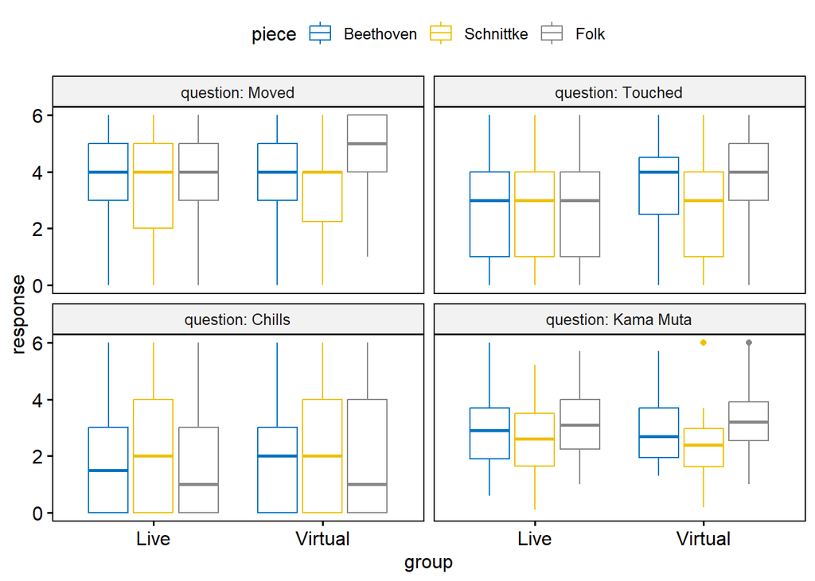

```r
bxp <- ggboxplot(
  data, x = "group", y = "response",
  color = "piece", palette = "jco",
  facet.by = "question", short.panel.labs = FALSE
  )
bxp
```

**Check assumptions for parametric testing** *outliers* 3 outliers in kama muta only, none extreme. No outliers in Moved or Touched.

```r
data %>%
  group_by(question, group, piece) %>%
  identify_outliers(response)
```

```
## # A tibble: 3 × 8
##   group   question  piece     Pt_ID  language response is.outlier is.extreme
##   <fct>   <fct>     <fct>     <fct>  <fct>       <dbl> <lgl>      <lgl>
## 1 Virtual Kama Muta Schnittke BEU126 English         6 TRUE       FALSE
## 2 Virtual Kama Muta Folk      BEQ108 English         6 TRUE       FALSE
## 3 Virtual Kama Muta Folk      BnS136 Danish          6 TRUE       FALSE
```

```r
# check only moved/touched because I am not sure if it IDs IQR based on the full data or just the question
data %>%
  filter(question == "Moved")%>%
  group_by(group, piece) %>%
  identify_outliers(response)
```

```
## [1] group      piece      Pt_ID      language   question   response   is.outlier
## [8] is.extreme
## <0 rows> (or 0-length row.names)
```

```r
data %>%
  filter(question == "Touched")%>%
  group_by(group, piece) %>%
  identify_outliers(response)
```

```
## [1] group      piece      Pt_ID      language   question   response   is.outlier
## [8] is.extreme
## <0 rows> (or 0-length row.names)
```

```r
data%>%
group_by(question, group, piece) %>%
  shapiro_test(response)
```

```
## # A tibble: 24 × 6
##    group   question piece     variable statistic         p
##    <fct>   <fct>    <fct>     <chr>        <dbl>     <dbl>
##  1 Live    Moved    Beethoven response     0.918 0.0000266
##  2 Live    Moved    Schnittke response     0.938 0.000509
##  3 Live    Moved    Folk      response     0.923 0.0000441
##  4 Virtual Moved    Beethoven response     0.933 0.0229
##  5 Virtual Moved    Schnittke response     0.938 0.0526
##  6 Virtual Moved    Folk      response     0.822 0.000170
##  7 Live    Touched  Beethoven response     0.927 0.0000751
##  8 Live    Touched  Schnittke response     0.931 0.000228
##  9 Live    Touched  Folk      response     0.913 0.0000158
## 10 Virtual Touched  Beethoven response     0.949 0.0778
## # … with 14 more rows
```

*QQplot* At high sample sizes such as our own, the shapiro test is easily violated. It also could be violated because this is interval rather than continuous data.

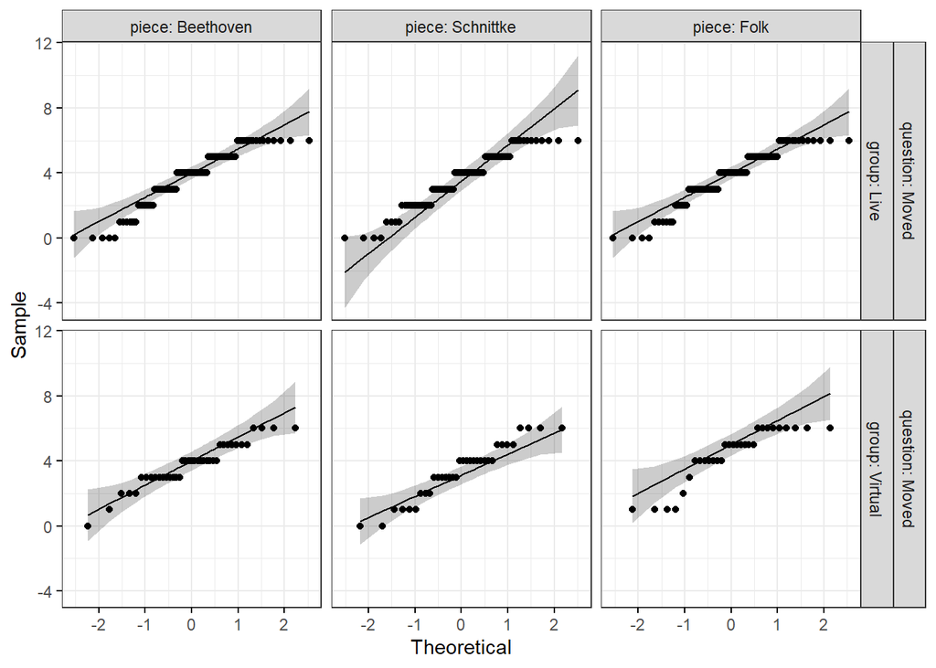

```r
data%>%
  filter(question == "Moved")%>%
  ggqqplot("response", ggtheme = theme_bw()) +
    facet_grid(question + group ~ piece, labeller = "label_both")
```

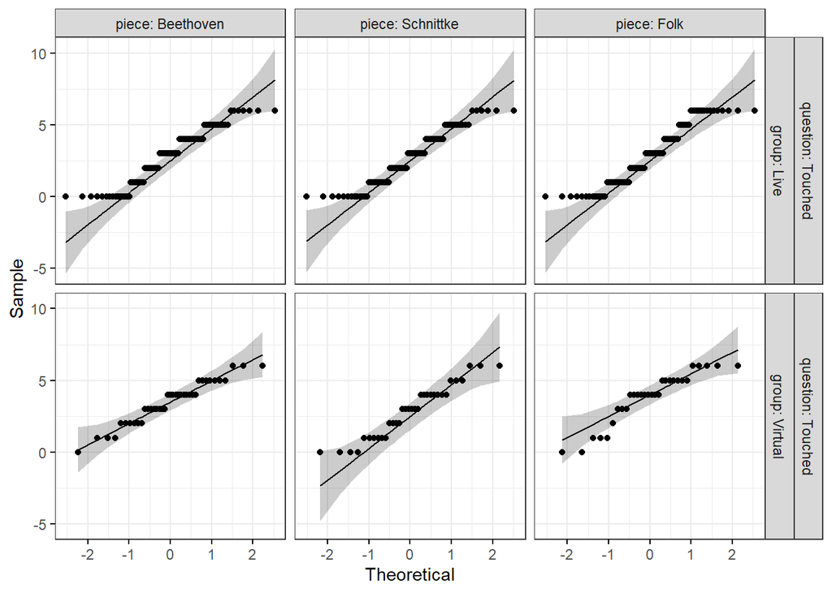

```r
# looks pretty bad because it is likert scale data

data%>%
  filter(question == "Touched")%>%
  ggqqplot("response", ggtheme = theme_bw()) +
    facet_grid(question + group ~ piece, labeller = "label_both")
```

*homogeneity of variance assumption* none violated

```r
data%>%
group_by(question, piece) %>%
  levene_test(response ~ group)
```

```
## # A tibble: 12 × 6
##    question  piece       df1   df2 statistic      p
##    <fct>     <fct>     <int> <int>     <dbl>  <dbl>
##  1 Moved     Beethoven     1   128   2.03    0.157
##  2 Moved     Schnittke     1   116   0.0136  0.907
##  3 Moved     Folk          1   119   0.00132 0.971
##  4 Touched   Beethoven     1   128   3.01    0.0850
##  5 Touched   Schnittke     1   116   0.118   0.731
##  6 Touched   Folk          1   118   2.68    0.104
##  7 Chills    Beethoven     1   127   0.167   0.683
##  8 Chills    Schnittke     1   119   0.0415  0.839
##  9 Chills    Folk          1   116   0.927   0.338
## 10 Kama Muta Beethoven     1   128   1.93    0.167
## 11 Kama Muta Schnittke     1   123   0.487   0.486
## 12 Kama Muta Folk          1   120   0.479   0.490
```

#### Aligned Ranks Transformation ANOVA

“ART ANOVA is a nonparametric approach that allows multiple independent variables, and repeated measures” - https://rcompanion.org/handbook/F_16.html

There were significantly more Danish people in the live audience and significantly more English people in the livestreaming audience therefore group does not make sense as a predictor here. Piece effects on kama muta have already been reported therefore I will only examine the effects and interaction of question and language.

```r
# fit model for only Moved and Touched
data_moved_language_model<-data%>%filter(question %in% c("Moved", "Touched"))
data_moved_language_model%>%group_by(question, language)%>%summarize(count = n())
```

```
## # A tibble: 4 × 3
## # Groups:   question [2]
##   question language count
##   <fct>    <fct>    <int>
## 1 Moved    Danish     242
## 2 Moved    English    127
## 3 Touched  Danish     240
## 4 Touched  English    128
```

```r
# need to represent this repeated measure of question because piece is not represented in the model
data_moved_language_model$question2<-data_moved_language_model$question

# random slope
moved_language_model_piece = art(response ~ piece*question*language + (1|Pt_ID), data = data_moved_language_model)
anova(moved_language_model_piece)
```

```
## Analysis of Variance of Aligned Rank Transformed Data
##
## Table Type: Analysis of Deviance Table (Type III Wald F tests with Kenward-Roger df)
## Model: Mixed Effects (lmer)
## Response: art(response)
##
##                                  F Df Df.res     Pr(>F)
## 1 piece                    5.70663  2 613.29 0.00350286  **
## 2 question                61.70436  1 592.90 1.8826e-14 ***
## 3 language                12.68791  1 134.91 0.00050919 ***
## 4 piece:question           0.28243  2 592.87 0.75405326
## 5 piece:language           2.66991  2 613.56 0.07006317   .
## 6 question:language       17.40511  1 592.90 3.4721e-05 ***
## 7 piece:question:language  0.58340  2 592.87 0.55831823
## ---
## Signif. codes:   0 '***' 0.001 '**' 0.01 '*' 0.05 '.' 0.1 ' ' 1
```

```r
# random slope
moved_language_model_rs = art(response ~ question*language + (1+question2|Pt_ID), data = data_moved_language_model)
anova(moved_language_model_rs)
```

```
## boundary (singular) fit: see help('isSingular')
## boundary (singular) fit: see help('isSingular')
## boundary (singular) fit: see help('isSingular')
```

```
## Analysis of Variance of Aligned Rank Transformed Data
##
## Table Type: Analysis of Deviance Table (Type III Wald F tests with Kenward-Roger df)
## Model: Mixed Effects (lmer)
## Response: art(response)
##
##                          F Df Df.res     Pr(>F)
## 1 question          45.579  1 130.70 4.3361e-10 ***
## 2 language          10.636  1 134.55 0.00140560  **
## 3 question:language 12.931  1 130.74 0.00045692 ***
## ---
## Signif. codes:   0 '***' 0.001 '**' 0.01 '*' 0.05 '.' 0.1 ' ' 1
```

```r
lang_quest_marginal_piece = art.con(moved_language_model_piece, "question:language", adjust = "Bonferroni")
```

```
## NOTE: Results may be misleading due to involvement in interactions
```

```r
lang_quest_marginal_piece # how do the df look here? Accurate? Except that this paired t-test must be flawed because it should actually be a comparison across 3 groups.
```

```
##  contrast                         estimate   SE  df t.ratio p.value
##  Moved,Danish - Moved,English        -55.9 29.4 189  -1.900  0.3539
##  Moved,Danish - Touched,Danish       120.4 13.8 593   8.739  <.0001
##  Moved,Danish - Touched,English      -13.7 29.4 188  -0.467  1.0000
##  Moved,English - Touched,Danish      176.3 29.5 190   5.985  <.0001
##  Moved,English - Touched,English      42.2 19.0 593   2.223  0.1597
##  Touched,Danish - Touched,English   -134.1 29.4 189  -4.558  0.0001
##
## Results are averaged over the levels of: piece
## Degrees-of-freedom method: kenward-roger
## P value adjustment: bonferroni method for 6 tests
```

```r
# Post-hoc comparisons: interaction Question and Language
lang_quest_marginal = art.con(moved_language_model_rs, "question:language", adjust = "Bonferroni")
```

```
## boundary (singular) fit: see help('isSingular')
```

```r
lang_quest_marginal
```

```
##  contrast                         estimate   SE  df t.ratio p.value
##  Moved,Danish - Moved,English        -44.8 28.3 135  -1.585  0.6914
##  Moved,Danish - Touched,Danish       115.6 13.7 123   8.455  <.0001
##  Moved,Danish - Touched,English       -7.2 29.5 176  -0.244  1.0000
##  Moved,English - Touched,Danish      160.4 29.0 180   5.529  <.0001
##  Moved,English - Touched,English      37.6 18.8 135   2.001  0.2845
##  Touched,Danish - Touched,English   -122.8 30.2 134  -4.065  0.0005
##
## Degrees-of-freedom method: kenward-roger
## P value adjustment: bonferroni method for 6 tests
```

#### Visualize

```r
data_moved_language_model_wider<-data_moved_language_model%>%pivot_wider(names_from = question, values_from = response)

vis.dat<-data_moved_language_model_wider%>%group_by(group, language, piece, Moved, Touched)%>%summarise(count = n())%>%ungroup()%>%mutate(ID = row_number())
```

[output not shown]

```r
vis.dat.long<-vis.dat%>%pivot_longer(!c(ID, group, language, piece, count),
                        names_to = "question",values_to = "response")

colours_DSQ<-c("#2d769a","#b34036")
Title= "Moved across pieces by language"
Pts<-data_moved_language_model_wider%>%group_by(Pt_ID, group, language)%>%summarize()%>%ungroup()
```

[output not shown]

[figure not shown]

```r
Subtitle = paste0("Live: ", Pts%>%filter(group == "Live")%>%count(), ", Livestreaming: ", Pts%>%filter(group == "Virtual")%>%count(),", Danish: ", Pts%>%filter(language =="Danish")%>%count(), ", English: ", Pts%>%filter(language == "English")%>%count())

vis.dat.long%>%
  ggplot(aes(x = question, y = response, group = ID,linewidth = count, color = group))+
  geom_line(alpha = 0.4)+
  labs(title=Title,
       subtitle = Subtitle)+
  theme_minimal()+
  scale_color_manual(values = colours_DSQ, name = "Concert Group")+
  xlab("Piece")+
  ylab("Response")+
  theme(axis.text.x = element_text(angle = 30))+
  theme(legend.position = "none")+
  facet_grid(language ~ piece)+
  theme(strip.text.x = element_text(size = 12), strip.text.y = element_text(size = 12, angle = 0))
```

```r
graphname = "../plots/Moved_Piece_Language_Lineweight.jpg"
ggsave(graphname, width = 20, height = 15, units = 'cm', dpi = 500)
```

[output not shown]

# 3.4 Motion and Emotion

## 3.4.1 mQoM

**Organize the data**

```r
dat<-df.full%>%select(Pt_ID, group, contains("mQoM"), contains("connected"), contains("KM"), contains("AWE_wonder"))

df.long<-dat%>%pivot_longer(!c(group, Pt_ID), #make long
                        names_to = c("question", "piece"),
                        names_pattern ="(.*)_(.*)",
                        values_to = "response")

df.wide<-df.long%>%pivot_wider(names_from = question, values_from = response)

df.wide<-df.wide%>%filter(piece %in% c("Beethoven", "Schnittke", "Folk"))

data<-df.wide%>%select(-connected_audience_attending, -connected_audience_streaming)

data$piece<-factor(data$piece, levels = c("Beethoven", "Schnittke", "Folk"))

# **Examine sample size and drop NA**
data%>%group_by(Pt_ID)%>%summarise(n=n()) # 110 participants; without dropping NA: 136
```

```
## # A tibble: 136 × 2
##    Pt_ID      n
##    <chr>  <int>
##  1 ADQ001     3
##  2 ADQ002     3
##  3 ADQ003     3
##  4 ADQ004     3
##  5 ADQ005     3
##  6 ADQ006     3
##  7 ADQ007     3
##  8 ADQ008     3
##  9 ADQ009     3
## 10 ADQ010     3
## # … with 126 more rows
```

```r
data%>%group_by(group, piece)%>%summarise(n=n()) # without dropping NA: LIVE: 91, virtual: 45
```

```
## # A tibble: 6 × 3
## # Groups:   group [2]
##   group   piece         n
##   <fct>   <fct>     <int>
## 1 Live    Beethoven    91
## 2 Live    Schnittke    91
## 3 Live    Folk         91
## 4 Virtual Beethoven    45
## 5 Virtual Schnittke    45
## 6 Virtual Folk         45
```

```r
data%>%drop_na()%>%group_by(group, piece)%>%summarise(n=n()) # Live = 72-81, Virtual = 16-25; without dropping NA: LIVE: 91, virtual: 45
```

```
## # A tibble: 6 × 3
## # Groups:   group [2]
##   group   piece         n
##   <fct>   <fct>     <int>
## 1 Live    Beethoven    81
## 2 Live    Schnittke    72
## 3 Live    Folk         75
## 4 Virtual Beethoven    25
## 5 Virtual Schnittke    18
## 6 Virtual Folk         16
```

```r
# keep for reference
data_with_na<-data

#Later you need to drop the NA anyways so you could consider doing it here to maintain consistency.
data_nona<-data%>%drop_na() #408 to 287
data<-data_nona
```

```r
mQoM_full<-lmer(mQoM ~ group + piece + group:piece + # concert
                  connected_musicians + connected_audience + KM + AWE_wonder + # emotions
                  connected_musicians:piece + connected_audience:piece + KM:piece + AWE_wonder:piece + # piece interactions
                  (1|Pt_ID),
                data = data)
```

```r
#check_model(mQoM_full)
```

Log transform

```r
data$log_mQoM<-log(data$mQoM) # fewer outliers identified with log transformation
```

```r
log_mQoM_full<-lmer(log_mQoM ~ group + piece + group:piece +# concert
                  connected_musicians + connected_audience + KM + AWE_wonder + # emotions
                  connected_musicians:piece + connected_audience:piece + KM:piece + AWE_wonder:piece + # piece interactions
                  (1|Pt_ID),
                data = data)
```

```r
#check_model(log_mQoM_full)
```

Remove the influential case 261

```r
data_u_ol<-data%>%dplyr::slice(-261L)
```

```r
# ID outliers
outliers<-data_u_ol %>%
  group_by(group, piece) %>%
  identify_outliers(log_mQoM)

outliers # 9 instances with log transformed data (compared to 17 with the normal data)
```

```
## # A tibble: 9 × 11
##   group  piece Pt_ID  mQoM conne…¹ conne…²    KM AWE_w…³ log_m…⁴ is.ou…⁵ is.ex…⁶
##   <fct>  <fct> <chr> <dbl>   <dbl>   <dbl> <dbl>   <dbl>   <dbl> <lgl>   <lgl>
## 1 Live   Beet… ADQ0… 0.166       0     0     0.9   0.857  -1.80  TRUE    FALSE
## 2 Live   Folk  AEQ0… 0.427       1     2     2.1   3      -0.852 TRUE    FALSE
## 3 Live   Folk  ADQ0… 0.307       5     4     3.1   3      -1.18  TRUE    FALSE
## 4 Virtu… Beet… BEQ1… 0.570       1     0     1.6   0.714  -0.562 TRUE    FALSE
## 5 Virtu… Beet… BDQ0… 0.460       0     1     1.8   2.86   -0.777 TRUE    FALSE
## 6 Virtu… Schn… BEQ1… 0.249       3     0     2     3.57   -1.39  TRUE    FALSE
## 7 Virtu… Schn… BEQ1… 0.325       2     1.5   2.7   2.29   -1.12  TRUE    FALSE
## 8 Virtu… Schn… BDQ0… 0.245       2     1     1.6   3      -1.41  TRUE    FALSE
## 9 Virtu… Folk  BEQ1… 0.486       3     0     3.8   2.71   -0.722 TRUE    TRUE
## # … with abbreviated variable names ¹connected_musicians, ²connected_audience,
## #   ³AWE_wonder, ⁴log_mQoM, ⁵is.outlier, ⁶is.extreme
```

```r
data_u_ol2<-data_u_ol%>% # 277 to 259
  group_by(group, piece) %>%
  filter(!is_outlier(log_mQoM))%>%
  ungroup()

data_u_ol2%>%group_by(group, piece)%>%summarise(n=n())
```

```
## # A tibble: 6 × 3
## # Groups:   group [2]
##   group   piece         n
##   <fct>   <fct>     <int>
## 1 Live    Beethoven    80
## 2 Live    Schnittke    72
## 3 Live    Folk         73
## 4 Virtual Beethoven    22
## 5 Virtual Schnittke    15
## 6 Virtual Folk         15
```

```r
log_mQoM_full_u_ol<-lmer(log_mQoM ~ group + piece + group:piece + # concert
                  connected_musicians + connected_audience + KM + AWE_wonder + # emotions
                  piece:connected_musicians + piece:connected_audience + piece:KM + piece:AWE_wonder + # piece interactions
                  (1|Pt_ID),
                data = data_u_ol2)
```

```r
#check_model(log_mQoM_full_u_ol)
check_heteroscedasticity(log_mQoM_full_u_ol) # yes heteroscedasticity is there.
model_dashboard(log_mQoM_full_u_ol, output_file = "QoM_dashboard.html")
```

```
##
##
## processing file: easydashboard.Rmd
```

[output not shown]

```
## output file: C:/Users/Dana/Documents/PhD/Research/MusicLab_Copenhagen/ML-Copenhagen-R-Project/Rmd/easydashboard.knit.md
```

[output not shown]

```
##
## Output created: QoM_dashboard.html
```

```r
r2(log_mQoM_full_u_ol)
```

```
## # R2 for Mixed Models
##
##   Conditional R2: 0.654
##      Marginal R2: 0.283
```

High VIF in the check model output may be acceptable because they are related to the interactions:

“2. The high VIFs are caused by the inclusion of powers or products of other variables. If you specify a regression model with both x and x2, there’s a good chance that those two variables will be highly correlated. Similarly, if your model has x, z, and xz, both x and z are likely to be highly correlated with their product. This is not something to be concerned about, however, because the p-value for xz is not affected by the multicollinearity. This is easily demonstrated: you can greatly reduce the correlations by “centering” the variables (i.e., subtracting their means) before creating the powers or the products. But the p-value for x2 or for xz will be exactly the same, regardless of whether or not you center. And all the results for the other variables (including the R2 but not including the lower-order terms) will be the same in either case. So the multicollinearity has no adverse consequences.” - https://statisticalhorizons.com/multicollinearity/

### Parameter estimates

```r
report_table(log_mQoM_full_u_ol)
```

```
## Parameter                               | Coefficient |         95% CI | t(257) |      p | Effects |    Group | Std. Coef. | Std. Coef. 95% CI |    Fit
## -------------------------------------------------------------------------------------------------------------------------------------------------------
## (Intercept)                             |       -2.33 | [-2.51, -2.15] | -25.93 | < .001 |   fixed |          |      -0.50 |    [-0.70, -0.30] |
## group [Virtual]                         |        0.40 | [ 0.25,  0.55] |   5.36 | < .001 |   fixed |          |       1.22 |    [ 0.77,  1.67] |
## piece [Schnittke]                       |        0.15 | [-0.07,  0.36] |   1.37 | 0.172  |   fixed |          |       0.26 |    [ 0.04,  0.48] |
## piece [Folk]                            |        0.17 | [-0.04,  0.39] |   1.59 | 0.112  |   fixed |          |       0.72 |    [ 0.48,  0.96] |
## connected musicians                     |       -0.03 | [-0.07,  0.02] |  -1.08 | 0.283  |   fixed |          |      -0.12 |    [-0.33,  0.10] |
## connected audience                      |        0.01 | [-0.03,  0.06] |   0.69 | 0.492  |   fixed |          |       0.07 |    [-0.13,  0.28] |
## KM                                      |    6.78e-03 | [-0.05,  0.07] |   0.23 | 0.822  |   fixed |          |       0.02 |    [-0.19,  0.24] |
## AWE wonder                              |       -0.03 | [-0.09,  0.03] |  -1.11 | 0.270  |   fixed |          |      -0.11 |    [-0.32,  0.09] |
## group [Virtual] × piece [Schnittke]     |       -0.27 | [-0.45, -0.09] |  -2.94 | 0.004  |   fixed |          |      -0.81 |    [-1.36, -0.27] |
## group [Virtual] × piece [Folk]          |       -0.21 | [-0.39, -0.03] |  -2.29 | 0.023  |   fixed |          |      -0.63 |    [-1.18, -0.09] |
## piece [Schnittke] × connected musicians |        0.02 | [-0.04,  0.08] |   0.67 | 0.504  |   fixed |          |       0.10 |    [-0.19,  0.39] |
## piece [Folk] × connected musicians      |        0.03 | [-0.03,  0.10] |   1.03 | 0.305  |   fixed |          |       0.16 |    [-0.15,  0.46] |
## piece [Schnittke] × connected audience  |       -0.02 | [-0.07,  0.03] |  -0.69 | 0.489  |   fixed |          |      -0.09 |    [-0.35,  0.17] |
## piece [Folk] × connected audience       |    9.84e-03 | [-0.04,  0.06] |   0.38 | 0.705  |   fixed |          |       0.05 |    [-0.21,  0.31] |
## piece [Schnittke] × KM                  |    7.90e-03 | [-0.07,  0.09] |   0.19 | 0.850  |   fixed |          |       0.03 |    [-0.27,  0.32] |
## piece [Folk] × KM                       |        0.05 | [-0.04,  0.13] |   1.14 | 0.257  |   fixed |          |       0.18 |    [-0.13,  0.49] |
## piece [Schnittke] × AWE wonder          |       -0.04 | [-0.11,  0.03] |  -1.24 | 0.216  |   fixed |          |      -0.15 |    [-0.38,  0.09] |
## piece [Folk] × AWE wonder               |       -0.08 | [-0.15,  0.00] |  -1.99 | 0.047  |   fixed |          |      -0.26 |    [-0.52,  0.00] |
##                                         |        0.21 |                |        |        |  random |    Pt_ID |            |                   |
##                                         |        0.20 |                |        |        |  random | Residual |            |                   |
##                                         |             |                |        |        |         |          |            |                   |
## AIC                                     |             |                |        |        |         |          |            |                   | 150.66
## AICc                                    |             |                |        |        |         |          |            |                   | 153.95
## BIC                                     |             |                |        |        |         |          |            |                   | 223.14
## R2 (conditional)                        |             |                |        |        |         |          |            |                   |   0.65
## R2 (marginal)                           |             |                |        |        |         |          |            |                   |   0.28
## Sigma                                   |             |                |        |        |         |          |            |                   |   0.20
```

```r
mp_satt<-model_parameters(log_mQoM_full_u_ol, ci_method = "satterthwaite", standardize = "refit")
mp_satt # copy and paste into excel, convert text to table, copy into word to apply formatting.
```

```
## # Fixed Effects
##
## Parameter                               | Coefficient |   SE |         95% CI |     t |     df |      p
## -------------------------------------------------------------------------------------------------------
## (Intercept)                             |       -0.50 | 0.10 | [-0.70, -0.30] | -4.97 | 196.99 | < .001
## group [Virtual]                         |        1.22 | 0.23 | [ 0.77,  1.67] |  5.36 | 217.31 | < .001
## piece [Schnittke]                       |        0.26 | 0.11 | [ 0.04,  0.48] |  2.31 | 160.70 | 0.022
## piece [Folk]                            |        0.72 | 0.12 | [ 0.48,  0.97] |  5.95 | 179.47 | < .001
## connected musicians                     |       -0.12 | 0.11 | [-0.33,  0.10] | -1.08 | 217.26 | 0.283
## connected audience                      |        0.07 | 0.11 | [-0.13,  0.28] |  0.69 | 228.30 | 0.492
## KM                                      |        0.02 | 0.11 | [-0.19,  0.24] |  0.23 | 224.99 | 0.822
## AWE wonder                              |       -0.11 | 0.10 | [-0.32,  0.09] | -1.11 | 235.59 | 0.270
## group [Virtual] × piece [Schnittke]     |       -0.81 | 0.28 | [-1.36, -0.27] | -2.94 | 178.11 | 0.004
## group [Virtual] × piece [Folk]          |       -0.63 | 0.28 | [-1.18, -0.09] | -2.29 | 186.76 | 0.023
## piece [Schnittke] × connected musicians |        0.10 | 0.15 | [-0.19,  0.39] |  0.67 | 180.41 | 0.504
## piece [Folk] × connected musicians      |        0.16 | 0.15 | [-0.15,  0.46] |  1.03 | 191.36 | 0.305
## piece [Schnittke] × connected audience  |       -0.09 | 0.13 | [-0.35,  0.17] | -0.69 | 171.37 | 0.490
## piece [Folk] × connected audience       |        0.05 | 0.13 | [-0.21,  0.31] |  0.38 | 188.70 | 0.706
## piece [Schnittke] × KM                  |        0.03 | 0.15 | [-0.27,  0.33] |  0.19 | 180.94 | 0.850
## piece [Folk] × KM                       |        0.18 | 0.16 | [-0.13,  0.49] |  1.14 | 192.66 | 0.258
## piece [Schnittke] × AWE wonder          |       -0.15 | 0.12 | [-0.38,  0.09] | -1.24 | 169.15 | 0.217
## piece [Folk] × AWE wonder               |       -0.26 | 0.13 | [-0.53,  0.00] | -1.99 | 177.72 | 0.048
##
## # Random Effects
##
## Parameter             | Coefficient |   SE |       95% CI
## ---------------------------------------------------------
## SD (Intercept: Pt_ID) |        0.63 | 0.06 | [0.52, 0.76]
## SD (Residual)         |        0.61 | 0.03 | [0.54, 0.68]
```

```
##
## Uncertainty intervals (equal-tailed) and p-values (two-tailed) computed
##   using a Wald t-distribution with Satterthwaite approximation.
```

Check how this compares to bootstrapping

```r
mp_bs<-model_parameters(log_mQoM_full_u_ol, ci_method = "hdi", standardize = "refit", bootstrap = TRUE, iterations = 500, verbose = FALSE)
mp_bs
```

```
## # Fixed Effects
##
## Parameter                               | Coefficient |         95% CI |      p
## -------------------------------------------------------------------------------
## (Intercept)                             |       -0.49 | [-0.71, -0.32] | < .001
## group [Virtual]                         |        1.22 | [ 0.82,  1.67] | < .001
## piece [Schnittke]                       |        0.25 | [ 0.04,  0.47] | 0.020
## piece [Folk]                            |        0.73 | [ 0.50,  0.98] | < .001
## connected musicians                     |       -0.11 | [-0.32,  0.09] | 0.272
## connected audience                      |        0.06 | [-0.14,  0.26] | 0.512
## KM                                      |        0.03 | [-0.18,  0.26] | 0.792
## AWE wonder                              |       -0.11 | [-0.32,  0.09] | 0.252
## group [Virtual] × piece [Schnittke]     |       -0.82 | [-1.38, -0.29] | 0.004
## group [Virtual] × piece [Folk]          |       -0.65 | [-1.20, -0.13] | 0.012
## piece [Schnittke] × connected musicians |        0.11 | [-0.17,  0.37] | 0.460
## piece [Folk] × connected musicians      |        0.16 | [-0.16,  0.44] | 0.324
## piece [Schnittke] × connected audience  |       -0.08 | [-0.35,  0.17] | 0.492
## piece [Folk] × connected audience       |        0.06 | [-0.21,  0.29] | 0.612
## piece [Schnittke] × KM                  |        0.02 | [-0.25,  0.32] | 0.884
## piece [Folk] × KM                       |        0.17 | [-0.16,  0.47] | 0.316
## piece [Schnittke] × AWE wonder          |       -0.14 | [-0.39,  0.10] | 0.276
## piece [Folk] × AWE wonder               |       -0.26 | [-0.51,  0.00] | 0.052
```

Examine the interaction between piee and group

```r
estimate_means(log_mQoM_full_u_ol, at = "piece")
```

```
## NOTE: Results may be misleading due to involvement in interactions
```

```
## Estimated Marginal Means
##
## piece     |  Mean |   SE |         95% CI
## -----------------------------------------
## Beethoven | -2.28 | 0.03 | [-2.35, -2.21]
## Schnittke | -2.33 | 0.05 | [-2.42, -2.24]
## Folk      | -2.14 | 0.04 | [-2.23, -2.06]
##
## Marginal means estimated at piece
```

```r
estimate_contrasts(log_mQoM_full_u_ol, contrast = "piece", at = "group")
```

```
## Marginal Contrasts Analysis
##
## Level1    |    Level2 |   group | Difference |         95% CI |   SE |     df |     t |      p
## ----------------------------------------------------------------------------------------------
## Beethoven |      Folk |    Live |      -0.24 | [-0.33, -0.14] | 0.04 | 184.66 | -5.93 | < .001
## Beethoven |      Folk | Virtual |      -0.03 | [-0.23,  0.17] | 0.08 | 195.69 | -0.36 | 0.717
## Beethoven | Schnittke |    Live |      -0.08 | [-0.17,  0.00] | 0.04 | 166.48 | -2.31 | 0.022
## Beethoven | Schnittke | Virtual |       0.18 | [-0.02,  0.39] | 0.08 | 187.82 |  2.16 | 0.066
## Schnittke |      Folk |    Live |      -0.15 | [-0.26, -0.05] | 0.04 | 198.96 | -3.55 | < .001
## Schnittke |      Folk | Virtual |      -0.21 | [-0.43,  0.01] | 0.09 | 186.69 | -2.31 | 0.066
##
## Marginal contrasts estimated at piece
## p-value adjustment method: Holm (1979)
```

```r
estimate_contrasts(log_mQoM_full_u_ol, contrast = "group", at = "piece")
```

```
## Marginal Contrasts Analysis
##
## Level1 |  Level2 |     piece | Difference |         95% CI |   SE |     df |     t |      p
## -------------------------------------------------------------------------------------------
## Live   | Virtual | Beethoven |      -0.40 | [-0.55, -0.25] | 0.07 | 220.56 | -5.35 | < .001
## Live   | Virtual |      Folk |      -0.19 | [-0.36, -0.03] | 0.08 | 243.26 | -2.29 | 0.023
## Live   | Virtual | Schnittke |      -0.13 | [-0.30,  0.03] | 0.09 | 248.46 | -1.57 | 0.118
##
## Marginal contrasts estimated at group
## p-value adjustment method: Holm (1979)
```

Estimate the awe x piece interaction

```r
slopes<-estimate_slopes(log_mQoM_full_u_ol, at = "piece", trend = "AWE_wonder")
slopes
```

```
## Estimated Marginal Effects
##
## piece     | Coefficient |   SE |         95% CI |     t |     df |      p
## -------------------------------------------------------------------------
## Beethoven |       -0.03 | 0.03 | [-0.09,  0.03] | -1.10 | 237.55 | 0.273
## Schnittke |       -0.08 | 0.03 | [-0.13, -0.02] | -2.88 | 237.04 | 0.004
## Folk      |       -0.11 | 0.03 | [-0.17, -0.05] | -3.47 | 239.64 | < .001
## Marginal effects estimated for AWE_wonder
```

### Visualize

Interaction between awe and piece

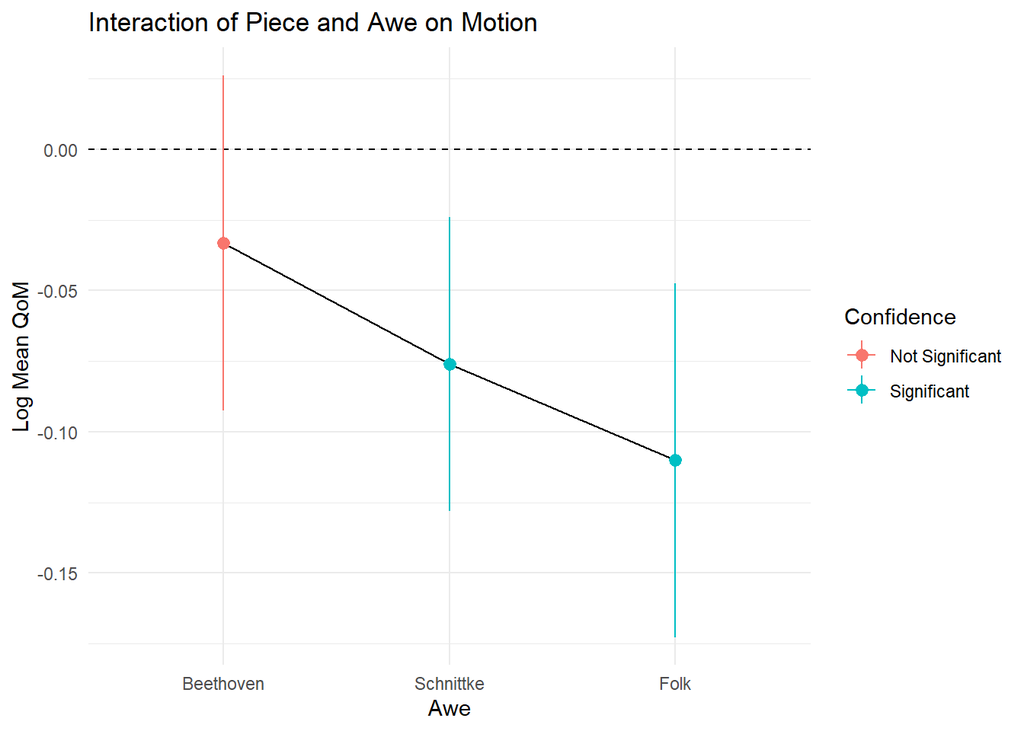

```r
# piece x awe
awe_plot<-plot(slopes)+
  labs(x = "Awe", y = "Log Mean QoM", title = "Interaction of Piece and Awe on Motion")+theme_minimal()

awe_plot
```

```r
piece_x_awe_grid<-get_datagrid(log_mQoM_full_u_ol, at = c("piece","AWE_wonder"))

piece_x_awe_audience_relation<-estimate_relation(log_mQoM_full_u_ol, data = piece_x_awe_grid)

vis<-visualisation_recipe(piece_x_awe_audience_relation, show_data = "point", point = list(alpha = .5, position = position_jitter(width = .2)))

trend_plot_awe<-plot(vis)+
  labs(title = "Interaction of Piece and Awe on Motion",
       x = "Awe",
       y = "Log Mean QoM")+
  theme_minimal()+
  theme(legend.title = element_blank())

graphname<-paste0("../plots/qom_piece_awe.jpg")
ggsave(graphname, width = 15, height = 9, units = 'cm', dpi = 500)
```

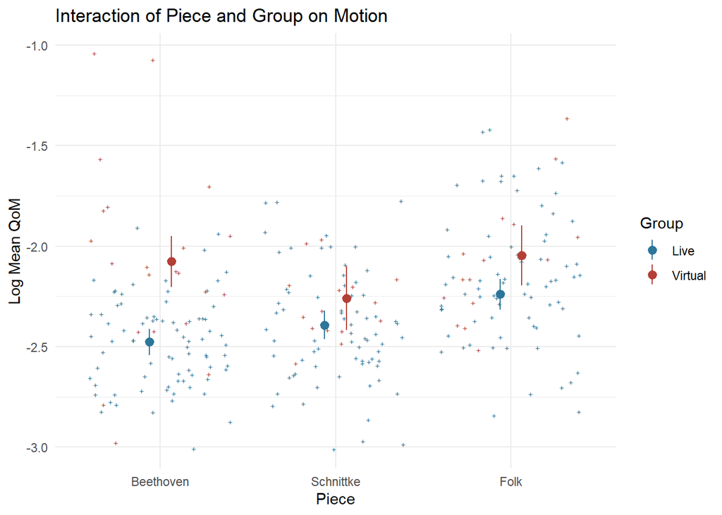

```r
# piece x group
pg_grid<-get_datagrid(log_mQoM_full_u_ol, at = c("piece","group"))

expected<-estimate_expectation(log_mQoM_full_u_ol, data = pg_grid)

colours_DSQ<-c("#2d769a","#b34036")

piece_group_qom_plot<-plot(expected)+
  labs(x = "Piece", y = "Log Mean QoM", title = "Interaction of Piece and Group on Motion")+
  scale_color_manual(values = colours_DSQ, name = "Group")+theme_minimal()
piece_group_qom_plot
```

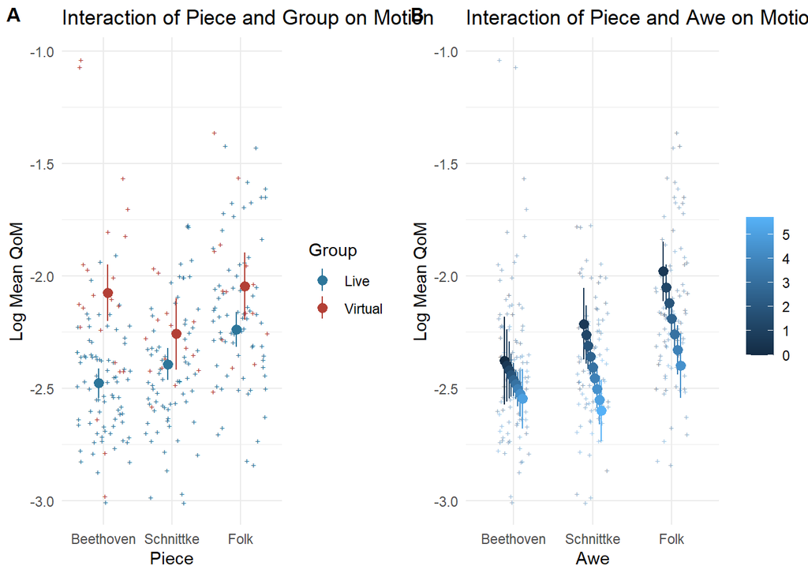

```r
plot_grid(piece_group_qom_plot, trend_plot_awe, labels = c('A', 'B'), label_size = 12)
```

```r
graphname<-paste0("../plots/Effect_Awe_piecegroup_QoM.jpg")
ggsave(graphname, width = 20, height = 9, units = 'cm', dpi = 500)
```

## 3.4.2 Stilling

**Organize the data**

```r
dat<-df.full%>%select(Pt_ID, group, contains("Stilling"), contains("connected"), contains("KM"), contains("AWE_wonder"))

df.long<-dat%>%pivot_longer(!c(group, Pt_ID), #make long
                        names_to = c("question", "piece"),
                        names_pattern ="(.*)_(.*)",
                        values_to = "response")

df.long$piece<-factor(df.long$piece, levels = c("Beethoven", "Schnittke","Bach", "Folk", "FullConcert")) #factor for the correct facet order

df.wide<-df.long%>%pivot_wider(names_from = question, values_from = response)

df.wide<-df.wide%>%filter(piece %in% c("Beethoven", "Schnittke", "Folk"))%>%filter(group == "Live") # removes Bach and virtual audiences

still<-df.wide%>%select(-connected_audience_attending, -connected_audience_streaming)%>%drop_na() #remove unnecessary cls and missing data
```

```r
still_full<-lmer(Stilling ~ piece + # concert
                  connected_musicians + connected_audience + KM + AWE_wonder + # emotions
                   piece:connected_musicians + piece:connected_audience + piece:KM + piece:AWE_wonder + # piece interactions
                  (1|Pt_ID),
                data = still)
```

No influential cases

```r
#check_model(still_full)
```

```r
# ID outliers
outliers<-still %>%
  group_by(group, piece) %>%
  identify_outliers(Stilling)

outliers # 4
```

```
## # A tibble: 4 × 10
##   group piece     Pt_ID  Stilling connec…¹ conne…²    KM AWE_w…³ is.ou…⁴ is.ex…⁵
##   <fct> <fct>     <chr>     <dbl>    <dbl>   <dbl> <dbl>   <dbl> <lgl>   <lgl>
## 1 Live  Beethoven AEQ079    0.379        5       4   5.2    4.29 TRUE    FALSE
## 2 Live  Folk      ADQ058    0.154        4       0   2.4    3    TRUE    TRUE
## 3 Live  Folk      ADQ029    0.205        6       6   4.4    3.57 TRUE    FALSE
## 4 Live  Folk      ADQ022    0.256        5       1   2.7    3.14 TRUE    FALSE
## # … with abbreviated variable names ¹connected_musicians, ²connected_audience,
## #   ³AWE_wonder, ⁴is.outlier, ⁵is.extreme
```

```r
still_u_ol<-still%>% # 277 to 259
  group_by(group, piece) %>%
  filter(!is_outlier(Stilling))%>%
  ungroup()

still_u_ol%>%group_by(group, piece)%>%summarise(n=n())
```

```
## # A tibble: 3 × 3
## # Groups:   group [1]
##   group piece         n
##   <fct> <fct>     <int>
## 1 Live  Beethoven    80
## 2 Live  Schnittke    72
## 3 Live  Folk         72
```

```r
still_full2<-lmer(Stilling ~ piece + # concert
                  connected_musicians + connected_audience + KM + AWE_wonder + # emotions
                   piece:connected_musicians + piece:connected_audience + piece:KM + piece:AWE_wonder + # piece interactions
                  (1|Pt_ID),
                data = still_u_ol)
```

```r
#check_model(still_full2) # linearity looks like it could also be violated. The QQ only looks poor at the very ends.
check_heteroscedasticity(still_full2) # yes heteroscedasticity is there.
model_dashboard(still_full2, output_file = "Stilling_dashboard.html")
```

```
##
##
## processing file: easydashboard.Rmd
```

[output not shown]

```
## output file: C:/Users/Dana/Documents/PhD/Research/MusicLab_Copenhagen/ML-Copenhagen-R-Project/Rmd/easydashboard.knit.md
```

[output not shown]

```
##
## Output created: Stilling_dashboard.html
```

```r
summary(still_full2)
```

```
## Linear mixed model fit by REML. t-tests use Satterthwaite's method [
## lmerModLmerTest]
## Formula: Stilling ~ piece + connected_musicians + connected_audience +
##     KM + AWE_wonder + piece:connected_musicians + piece:connected_audience +
##     piece:KM + piece:AWE_wonder + (1 | Pt_ID)
##    Data: still_u_ol
##
## REML criterion at convergence: -388.5
##
## Scaled residuals:
##      Min       1Q   Median       3Q      Max
## -2.58587 -0.52308  0.05769  0.58926  2.46674
##
## Random effects:
##  Groups   Name        Variance Std.Dev.
##  Pt_ID    (Intercept) 0.001159 0.03405
##  Residual             0.005621 0.07498
## Number of obs: 224, groups:  Pt_ID, 84
##
## Fixed effects:
##                                      Estimate Std. Error         df t value
## (Intercept)                          0.546495   0.029762 208.804546  18.362
## pieceSchnittke                      -0.010455   0.040946 148.775113  -0.255
## pieceFolk                           -0.016544   0.041446 161.016308  -0.399
## connected_musicians                 -0.014826   0.008681 203.145369  -1.708
## connected_audience                   0.015750   0.007660 206.464947   2.056
## KM                                  -0.001837   0.011450 204.899913  -0.160
## AWE_wonder                           0.006202   0.010716 207.282348   0.579
## pieceSchnittke:connected_musicians   0.031456   0.012164 170.824918   2.586
## pieceFolk:connected_musicians        0.007859   0.012730 190.970926   0.617
## pieceSchnittke:connected_audience   -0.014869   0.010202 165.457601  -1.457
## pieceFolk:connected_audience        -0.004426   0.010349 191.711374  -0.428
## pieceSchnittke:KM                   -0.009498   0.016338 173.447858  -0.581
## pieceFolk:KM                         0.014005   0.017059 186.414001   0.821
## pieceSchnittke:AWE_wonder           -0.013182   0.013566 156.409983  -0.972
## pieceFolk:AWE_wonder                -0.009033   0.015144 165.918179  -0.596
##                                    Pr(>|t|)
## (Intercept)                          <2e-16 ***
## pieceSchnittke                       0.7988
## pieceFolk                            0.6903
## connected_musicians                  0.0892 .
## connected_audience                   0.0410 *
## KM                                   0.8727
## AWE_wonder                           0.5634
## pieceSchnittke:connected_musicians   0.0105 *
## pieceFolk:connected_musicians        0.5378
## pieceSchnittke:connected_audience    0.1469
## pieceFolk:connected_audience         0.6694
## pieceSchnittke:KM                    0.5618
## pieceFolk:KM                         0.4127
## pieceSchnittke:AWE_wonder            0.3327
## pieceFolk:AWE_wonder                 0.5517
## ---
## Signif. codes:  0 '***' 0.001 '**' 0.01 '*' 0.05 '.' 0.1 ' ' 1
```

```
##
## Correlation matrix not shown by default, as p = 15 > 12.
## Use print(x, correlation=TRUE)  or
##     vcov(x)        if you need it
```

```r
r2(still_full2)
```

```
## # R2 for Mixed Models
##
##   Conditional R2: 0.227
##      Marginal R2: 0.068
```

### Parameter estimates

```r
mp_satt<-model_parameters(still_full2, ci_method = "satterthwaite", standardize = "refit")
mp_satt # copy and paste into excel, convert text to table, copy into word to apply formatting.
```

```
## # Fixed Effects
##
## Parameter                               | Coefficient |   SE |        95% CI |     t |     df |     p
## -----------------------------------------------------------------------------------------------------
## (Intercept)                             |       -0.14 | 0.11 | [-0.36, 0.09] | -1.20 | 199.75 | 0.232
## piece [Schnittke]                       |        0.10 | 0.16 | [-0.22, 0.42] |  0.62 | 141.84 | 0.536
## piece [Folk]                            |        0.18 | 0.17 | [-0.16, 0.53] |  1.05 | 164.93 | 0.295
## connected musicians                     |       -0.29 | 0.17 | [-0.62, 0.04] | -1.71 | 203.15 | 0.089
## connected audience                      |        0.30 | 0.15 | [ 0.01, 0.59] |  2.06 | 206.46 | 0.041
## KM                                      |       -0.03 | 0.16 | [-0.35, 0.30] | -0.16 | 204.90 | 0.873
## AWE wonder                              |        0.09 | 0.15 | [-0.21, 0.38] |  0.58 | 207.28 | 0.563
## piece [Schnittke] × connected musicians |        0.62 | 0.24 | [ 0.15, 1.08] |  2.59 | 170.82 | 0.011
## piece [Folk] × connected musicians      |        0.15 | 0.25 | [-0.34, 0.64] |  0.62 | 190.97 | 0.538
## piece [Schnittke] × connected audience  |       -0.28 | 0.19 | [-0.67, 0.10] | -1.46 | 165.46 | 0.147
## piece [Folk] × connected audience       |       -0.08 | 0.20 | [-0.47, 0.31] | -0.43 | 191.71 | 0.669
## piece [Schnittke] × KM                  |       -0.14 | 0.23 | [-0.60, 0.32] | -0.58 | 173.45 | 0.562
## piece [Folk] × KM                       |        0.20 | 0.24 | [-0.28, 0.68] |  0.82 | 186.41 | 0.413
## piece [Schnittke] × AWE wonder          |       -0.18 | 0.19 | [-0.55, 0.19] | -0.97 | 156.41 | 0.333
## piece [Folk] × AWE wonder               |       -0.12 | 0.21 | [-0.54, 0.29] | -0.60 | 165.92 | 0.552
##
## # Random Effects
##
## Parameter             | Coefficient |   SE |       95% CI
## ---------------------------------------------------------
## SD (Intercept: Pt_ID) |        0.41 | 0.10 | [0.25, 0.68]
## SD (Residual)         |        0.91 | 0.06 | [0.81, 1.03]
```

```
##
## Uncertainty intervals (equal-tailed) and p-values (two-tailed) computed
##   using a Wald t-distribution with Satterthwaite approximation.
```

Given that Satterthwaite approximation could be incorrect, check how this compares to bootstrapping

```r
mp_bs<-model_parameters(still_full2, bootstrap = TRUE, iterations = 500, verbose = FALSE)
mp_bs
```

```
## # Fixed Effects
##
## Parameter                               | Coefficient |        95% CI |      p
## ------------------------------------------------------------------------------
## (Intercept)                             |        0.55 | [ 0.49, 0.60] | < .001
## piece [Schnittke]                       |       -0.01 | [-0.09, 0.07] | 0.788
## piece [Folk]                            |       -0.02 | [-0.10, 0.07] | 0.644
## connected musicians                     |       -0.02 | [-0.03, 0.00] | 0.080
## connected audience                      |        0.02 | [ 0.00, 0.03] | 0.056
## KM                                      |   -2.53e-03 | [-0.02, 0.02] | 0.848
## AWE wonder                              |    6.16e-03 | [-0.02, 0.03] | 0.540
## piece [Schnittke] × connected musicians |        0.03 | [ 0.01, 0.06] | 0.008
## piece [Folk] × connected musicians      |    7.85e-03 | [-0.02, 0.03] | 0.524
## piece [Schnittke] × connected audience  |       -0.01 | [-0.04, 0.00] | 0.164
## piece [Folk] × connected audience       |   -4.08e-03 | [-0.02, 0.02] | 0.724
## piece [Schnittke] × KM                  |   -8.10e-03 | [-0.04, 0.02] | 0.560
## piece [Folk] × KM                       |        0.01 | [-0.02, 0.04] | 0.420
## piece [Schnittke] × AWE wonder          |       -0.01 | [-0.04, 0.01] | 0.340
## piece [Folk] × AWE wonder               |   -8.27e-03 | [-0.04, 0.02] | 0.568
```

```r
mp_bs2<-model_parameters(still_full2, ci_method = "hdi", standardize = "refit", bootstrap = TRUE, iterations = 500, verbose = FALSE)
mp_bs2
```

```
## # Fixed Effects
##
## Parameter                               | Coefficient |        95% CI |     p
## -----------------------------------------------------------------------------
## (Intercept)                             |       -0.14 | [-0.35, 0.07] | 0.228
## piece [Schnittke]                       |        0.11 | [-0.22, 0.42] | 0.504
## piece [Folk]                            |        0.18 | [-0.15, 0.54] | 0.300
## connected musicians                     |       -0.28 | [-0.63, 0.06] | 0.092
## connected audience                      |        0.29 | [ 0.03, 0.58] | 0.012
## KM                                      |       -0.01 | [-0.35, 0.30] | 0.916
## AWE wonder                              |        0.08 | [-0.21, 0.34] | 0.556
## piece [Schnittke] × connected musicians |        0.62 | [ 0.16, 1.09] | 0.012
## piece [Folk] × connected musicians      |        0.15 | [-0.36, 0.64] | 0.596
## piece [Schnittke] × connected audience  |       -0.28 | [-0.66, 0.08] | 0.092
## piece [Folk] × connected audience       |       -0.07 | [-0.45, 0.30] | 0.716
## piece [Schnittke] × KM                  |       -0.14 | [-0.62, 0.28] | 0.576
## piece [Folk] × KM                       |        0.23 | [-0.28, 0.66] | 0.384
## piece [Schnittke] × AWE wonder          |       -0.18 | [-0.56, 0.18] | 0.376
## piece [Folk] × AWE wonder               |       -0.13 | [-0.50, 0.27] | 0.520
```

Examine the interaction between connectedness to the musicians and piece on stilling

```r
slopes<-estimate_slopes(still_full2, at = "piece", trend = "connected_musicians")
slopes
```

```
## Estimated Marginal Effects
##
## piece     | Coefficient |       SE |        95% CI |     t |     df |     p
## ---------------------------------------------------------------------------
## Beethoven |       -0.01 | 8.75e-03 | [-0.03, 0.00] | -1.69 | 203.70 | 0.092
## Schnittke |        0.02 | 9.14e-03 | [ 0.00, 0.03] |  1.82 | 203.37 | 0.070
## Folk      |   -6.97e-03 | 9.64e-03 | [-0.03, 0.01] | -0.72 | 204.68 | 0.471
## Marginal effects estimated for connected_musicians
```

```r
contrasts<-estimate_contrasts(still_full2, at = "piece", contrast = "connected_musicians")
contrasts
```

```
## Marginal Contrasts Analysis
##
## Level1                               |                               Level2 |     piece | Difference |        95% CI |       SE |     df |     t |      p
## ---------------------------------------------------------------------------------------------------------------------------------------------------------
## connected_musicians0                 | connected_musicians0.666666666666667 | Beethoven |   9.88e-03 | [-0.01, 0.03] | 5.83e-03 | 203.70 |  1.69 | > .999
## connected_musicians0                 | connected_musicians0.666666666666667 |      Folk |   4.64e-03 | [-0.02, 0.03] | 6.43e-03 | 204.68 |  0.72 | > .999
## connected_musicians0                 | connected_musicians0.666666666666667 | Schnittke |      -0.01 | [-0.03, 0.01] | 6.10e-03 | 203.37 | -1.82 | > .999
## connected_musicians0                 |  connected_musicians1.33333333333333 | Beethoven |       0.02 | [-0.02, 0.06] |     0.01 | 203.70 |  1.69 | > .999
## connected_musicians0                 |  connected_musicians1.33333333333333 |      Folk |   9.29e-03 | [-0.03, 0.05] |     0.01 | 204.68 |  0.72 | > .999
## connected_musicians0                 |  connected_musicians1.33333333333333 | Schnittke |      -0.02 | [-0.06, 0.02] |     0.01 | 203.37 | -1.82 | > .999
## connected_musicians0                 |                 connected_musicians2 | Beethoven |       0.03 | [-0.03, 0.09] |     0.02 | 203.70 |  1.69 | > .999
## connected_musicians0                 |                 connected_musicians2 |      Folk |       0.01 | [-0.05, 0.08] |     0.02 | 204.68 |  0.72 | > .999
## connected_musicians0                 |                 connected_musicians2 | Schnittke |      -0.03 | [-0.09, 0.03] |     0.02 | 203.37 | -1.82 | > .999
## connected_musicians0                 |  connected_musicians2.66666666666667 | Beethoven |       0.04 | [-0.04, 0.12] |     0.02 | 203.70 |  1.69 | > .999
## connected_musicians0                 |  connected_musicians2.66666666666667 |      Folk |       0.02 | [-0.07, 0.10] |     0.03 | 204.68 |  0.72 | > .999
## connected_musicians0                 |  connected_musicians2.66666666666667 | Schnittke |      -0.04 | [-0.13, 0.04] |     0.02 | 203.37 | -1.82 | > .999
## connected_musicians0                 |  connected_musicians3.33333333333333 | Beethoven |       0.05 | [-0.05, 0.15] |     0.03 | 203.70 |  1.69 | > .999
## connected_musicians0                 |  connected_musicians3.33333333333333 |      Folk |       0.02 | [-0.08, 0.13] |     0.03 | 204.68 |  0.72 | > .999
## connected_musicians0                 |  connected_musicians3.33333333333333 | Schnittke |      -0.06 | [-0.16, 0.05] |     0.03 | 203.37 | -1.82 | > .999
## connected_musicians0                 |                 connected_musicians4 | Beethoven |       0.06 | [-0.06, 0.18] |     0.03 | 203.70 |  1.69 | > .999
## connected_musicians0                 |                 connected_musicians4 |      Folk |       0.03 | [-0.10, 0.16] |     0.04 | 204.68 |  0.72 | > .999
## connected_musicians0                 |                 connected_musicians4 | Schnittke |      -0.07 | [-0.19, 0.05] |     0.04 | 203.37 | -1.82 | > .999
## connected_musicians0                 |  connected_musicians4.66666666666667 | Beethoven |       0.07 | [-0.07, 0.20] |     0.04 | 203.70 |  1.69 | > .999
## connected_musicians0                 |  connected_musicians4.66666666666667 |      Folk |       0.03 | [-0.12, 0.18] |     0.05 | 204.68 |  0.72 | > .999
## connected_musicians0                 |  connected_musicians4.66666666666667 | Schnittke |      -0.08 | [-0.22, 0.06] |     0.04 | 203.37 | -1.82 | > .999
## connected_musicians0                 |  connected_musicians5.33333333333333 | Beethoven |       0.08 | [-0.08, 0.23] |     0.05 | 203.70 |  1.69 | > .999
## connected_musicians0                 |  connected_musicians5.33333333333333 |      Folk |       0.04 | [-0.13, 0.21] |     0.05 | 204.68 |  0.72 | > .999
## connected_musicians0                 |  connected_musicians5.33333333333333 | Schnittke |      -0.09 | [-0.25, 0.07] |     0.05 | 203.37 | -1.82 | > .999
## connected_musicians0                 |                 connected_musicians6 | Beethoven |       0.09 | [-0.08, 0.26] |     0.05 | 203.70 |  1.69 | > .999
## connected_musicians0                 |                 connected_musicians6 |      Folk |       0.04 | [-0.15, 0.23] |     0.06 | 204.68 |  0.72 | > .999
## connected_musicians0                 |                 connected_musicians6 | Schnittke |      -0.10 | [-0.28, 0.08] |     0.05 | 203.37 | -1.82 | > .999
## connected_musicians0.666666666666667 |  connected_musicians1.33333333333333 | Beethoven |   9.88e-03 | [-0.01, 0.03] | 5.83e-03 | 203.70 |  1.69 | > .999
## connected_musicians0.666666666666667 |  connected_musicians1.33333333333333 |      Folk |   4.64e-03 | [-0.02, 0.03] | 6.43e-03 | 204.68 |  0.72 | > .999
## connected_musicians0.666666666666667 |  connected_musicians1.33333333333333 | Schnittke |      -0.01 | [-0.03, 0.01] | 6.10e-03 | 203.37 | -1.82 | > .999
## connected_musicians0.666666666666667 |                 connected_musicians2 | Beethoven |       0.02 | [-0.02, 0.06] |     0.01 | 203.70 |  1.69 | > .999
## connected_musicians0.666666666666667 |                 connected_musicians2 |      Folk |   9.29e-03 | [-0.03, 0.05] |     0.01 | 204.68 |  0.72 | > .999
## connected_musicians0.666666666666667 |                 connected_musicians2 | Schnittke |      -0.02 | [-0.06, 0.02] |     0.01 | 203.37 | -1.82 | > .999
## connected_musicians0.666666666666667 |  connected_musicians2.66666666666667 | Beethoven |       0.03 | [-0.03, 0.09] |     0.02 | 203.70 |  1.69 | > .999
## connected_musicians0.666666666666667 |  connected_musicians2.66666666666667 |      Folk |       0.01 | [-0.05, 0.08] |     0.02 | 204.68 |  0.72 | > .999
## connected_musicians0.666666666666667 |  connected_musicians2.66666666666667 | Schnittke |      -0.03 | [-0.09, 0.03] |     0.02 | 203.37 | -1.82 | > .999
```

[output cut: 87 more lines]

```
## connected_musicians4                 |                 connected_musicians6 | Beethoven |       0.03 | [-0.03, 0.09] |     0.02 | 203.70 |  1.69 | > .999
## connected_musicians4                 |                 connected_musicians6 |      Folk |       0.01 | [-0.05, 0.08] |     0.02 | 204.68 |  0.72 | > .999
## connected_musicians4                 |                 connected_musicians6 | Schnittke |      -0.03 | [-0.09, 0.03] |     0.02 | 203.37 | -1.82 | > .999
## connected_musicians4.66666666666667  |  connected_musicians5.33333333333333 | Beethoven |   9.88e-03 | [-0.01, 0.03] | 5.83e-03 | 203.70 |  1.69 | > .999
## connected_musicians4.66666666666667  |  connected_musicians5.33333333333333 |      Folk |   4.64e-03 | [-0.02, 0.03] | 6.43e-03 | 204.68 |  0.72 | > .999
## connected_musicians4.66666666666667  |  connected_musicians5.33333333333333 | Schnittke |      -0.01 | [-0.03, 0.01] | 6.10e-03 | 203.37 | -1.82 | > .999
## connected_musicians4.66666666666667  |                 connected_musicians6 | Beethoven |       0.02 | [-0.02, 0.06] |     0.01 | 203.70 |  1.69 | > .999
## connected_musicians4.66666666666667  |                 connected_musicians6 |      Folk |   9.29e-03 | [-0.03, 0.05] |     0.01 | 204.68 |  0.72 | > .999
## connected_musicians4.66666666666667  |                 connected_musicians6 | Schnittke |      -0.02 | [-0.06, 0.02] |     0.01 | 203.37 | -1.82 | > .999
## connected_musicians5.33333333333333  |                 connected_musicians6 | Beethoven |   9.88e-03 | [-0.01, 0.03] | 5.83e-03 | 203.70 |  1.69 | > .999
## connected_musicians5.33333333333333  |                 connected_musicians6 |      Folk |   4.64e-03 | [-0.02, 0.03] | 6.43e-03 | 204.68 |  0.72 | > .999
## connected_musicians5.33333333333333  |                 connected_musicians6 | Schnittke |      -0.01 | [-0.03, 0.01] | 6.10e-03 | 203.37 | -1.82 | > .999
##
## Marginal contrasts estimated at connected_musicians
## p-value adjustment method: Holm (1979)
```

```r
means<-estimate_means(still_full2, at = "piece", fixed = "connected_musicians")
means
```

```
## Estimated Marginal Means
##
## piece     | connected_musicians | Mean |       SE |       95% CI
## ----------------------------------------------------------------
## Beethoven |                3.94 | 0.54 | 9.30e-03 | [0.52, 0.56]
## Schnittke |                3.94 | 0.55 |     0.01 | [0.53, 0.57]
## Folk      |                3.94 | 0.56 |     0.01 | [0.53, 0.58]
##
## Marginal means estimated at piece
```

### Visualize

Main effect of connected audience on stilling: would not plot without the reduced model.

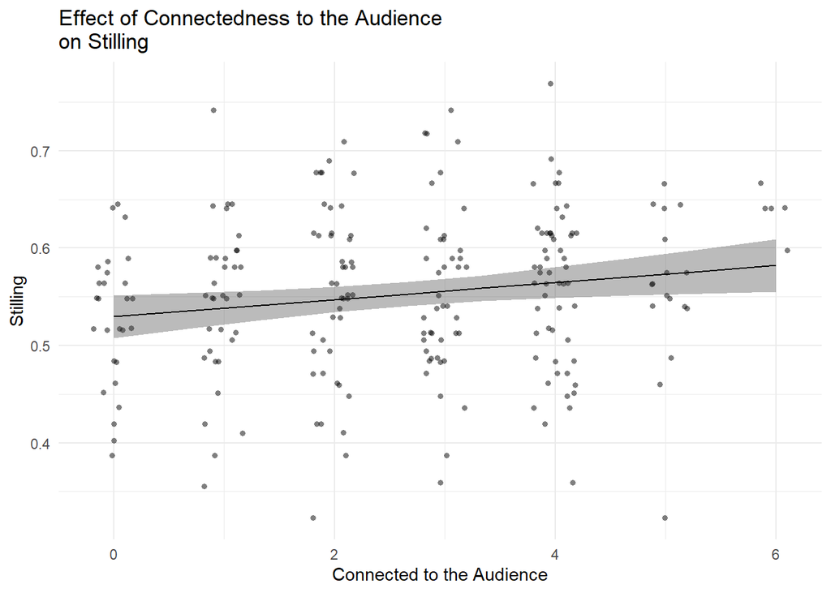

```r
connAud_still<-lmer(Stilling ~ connected_audience + (1|Pt_ID), data = still_u_ol)

connAud_grid<-get_datagrid(connAud_still, at = "connected_audience")

expected<-estimate_expectation(connAud_still, data = connAud_grid)

connAud_plot<-plot(visualisation_recipe(expected, show_data = "point", point = list(alpha = .5, position = position_jitter(width = .2))))+labs(x = "Connected to the Audience", y = "Stilling", title = "Effect of Connectedness to the Audience \non Stilling")+theme_minimal()

connAud_plot
```

```r
graphname<-paste0("../plots/EffectConnAud_Stilling.jpg")
ggsave(graphname, width = 12, height = 7, units = 'cm', dpi = 500)
```

Interaction between connected to the musicians and piece

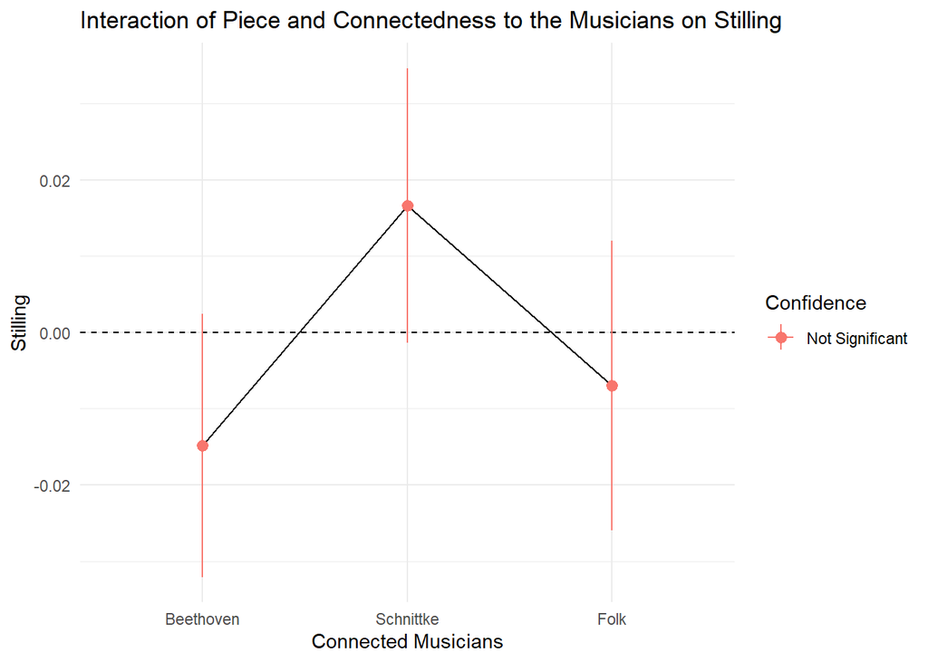

```r
# piece x con_mus
connmus_plot<-plot(slopes)+
  labs(x = "Connected Musicians", y = "Stilling", title = "Interaction of Piece and Connectedness to the Musicians on Stilling")+theme_minimal()

connmus_plot
```

```r
piece_x_connected_musicians_grid<-get_datagrid(still_full2, at = c("piece","connected_musicians"))

piece_x_connected_musicians_relation<-estimate_relation(still_full2, data = piece_x_connected_musicians_grid)

vis<-visualisation_recipe(piece_x_connected_musicians_relation, show_data = "point", point = list(alpha = .5, position = position_jitter(width = .2)))

ixn_piece_conmus_still<-plot(vis)+
  labs(title = "Effect of Piece and Connectedness to the \nMusicians on Stilling",
       x = "Connectedness to the Musicians",
       y = "Stilling")+
  theme_minimal()+
  theme(legend.title = element_blank())

graphname<-paste0("../plots/still_piece_connMus.jpg")
ggsave(graphname, width = 15, height = 9, units = 'cm', dpi = 500)
```

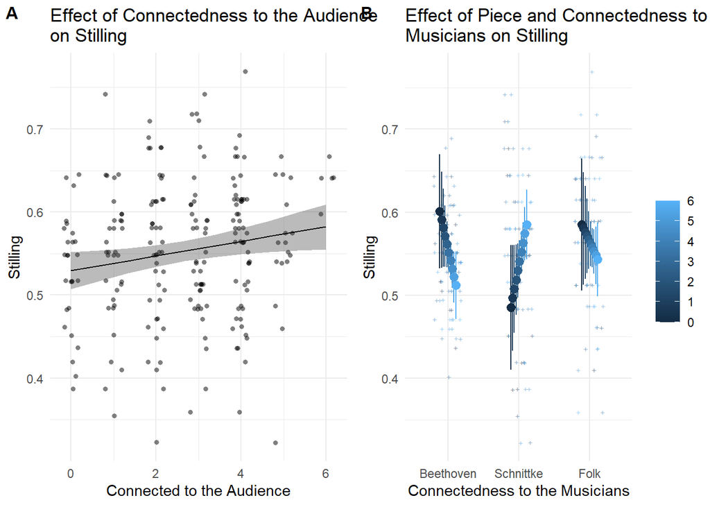

```r
plot_grid(connAud_plot, ixn_piece_conmus_still, labels = c('A', 'B'), label_size = 12)
```

```r
graphname<-paste0("../plots/Stilling_Connected_Plots.jpg")
ggsave(graphname, width = 20, height = 9, units = 'cm', dpi = 500)
```

## 3.4.3 Neighbours’ motion

```r
dat<-df.full%>%select(Pt_ID, group, contains('Motion_seen'), contains("connected"), contains("KM"), contains("AWE_wonder"))

df.long<-dat%>%pivot_longer(!c(group, Pt_ID), #make long
                        names_to = c("question", "piece"),
                        names_pattern ="(.*)_(.*)",
                        values_to = "response")

df.long$piece<-factor(df.long$piece, levels = c("Beethoven", "Schnittke","Bach", "Folk", "FullConcert")) #factor for the correct facet order

df.wide<-df.long%>%pivot_wider(names_from = question, values_from = response)

df.wide<-df.wide%>%filter(piece %in% c("Beethoven", "Schnittke", "Folk"))%>%filter(group == "Live") # removes Bach and virtual audiences

data<-df.wide%>%select(-connected_audience_attending, -connected_audience_streaming)%>%drop_na() #remove unnecessary cols and missing data

#rename
data%<>%rename("seen" = "Motion_seen",
              "seen_max" = "Motion_seen_Max")

seen<-data
```

```r
seen_full<-lmer(seen ~ piece + # concert
                  connected_musicians + connected_audience + KM + AWE_wonder + # emotions
                   piece:connected_musicians + piece:connected_audience + piece:KM + piece:AWE_wonder + # piece interactions
                  (1|Pt_ID),
                data = seen)
```

```r
#check_model(seen_full) # looks bad at the tail

check_outliers(seen_full)
```

```
## OK: No outliers detected.
## - Based on the following method and threshold: cook (0.96).
## - For variable: (Whole model)
```

```r
# ID outliers
outliers<-seen %>%
  group_by(group, piece) %>%
  identify_outliers(seen)

outliers # 8
```

```
## # A tibble: 8 × 11
##   group piece Pt_ID   seen seen_…¹ conne…² conne…³    KM AWE_w…⁴ is.ou…⁵ is.ex…⁶
##   <fct> <fct> <chr>  <dbl>   <dbl>   <dbl>   <dbl> <dbl>   <dbl> <lgl>   <lgl>
## 1 Live  Beet… ADQ0… 0.128   0.144        5       5   3.6    3.14 TRUE    FALSE
## 2 Live  Schn… ADQ0… 0.140   0.177        3       1   2.5    4.43 TRUE    FALSE
## 3 Live  Folk  AEQ0… 0.207   0.307        6       5   4.4    4.14 TRUE    TRUE
## 4 Live  Folk  ADQ0… 0.186   0.307        5       4   2.1    1.86 TRUE    FALSE
## 5 Live  Folk  ADQ0… 0.167   0.240        5       4   4      3.57 TRUE    FALSE
## 6 Live  Folk  ADQ0… 0.182   0.307        5       5   4.1    2.71 TRUE    FALSE
## 7 Live  Folk  ADQ0… 0.200   0.200        6       4   4.3    3.14 TRUE    FALSE
## 8 Live  Folk  ADQ0… 0.0594  0.0594       6       6   4.4    3.57 TRUE    FALSE
## # … with abbreviated variable names ¹seen_max, ²connected_musicians,
## #   ³connected_audience, ⁴AWE_wonder, ⁵is.outlier, ⁶is.extreme
```

```r
seen_u_ol<-seen%>% # 277 to 259
  group_by(group, piece) %>%
  filter(!is_outlier(seen))%>%
  ungroup()

seen_u_ol%>%group_by(group, piece)%>%summarise(n=n())
```

```
## # A tibble: 3 × 3
## # Groups:   group [1]
##   group piece         n
##   <fct> <fct>     <int>
## 1 Live  Beethoven    79
## 2 Live  Schnittke    73
## 3 Live  Folk         73
```

```r
seen_full2<-lmer(seen ~ piece + # concert
                  connected_musicians + connected_audience + KM + AWE_wonder + # emotions
                   piece:connected_musicians + piece:connected_audience + piece:KM + piece:AWE_wonder + # piece interactions
                  (1|Pt_ID),
                data = seen_u_ol)
```

```r
#check_model(seen_full2) # this looks worse than mQoM to me
check_heteroscedasticity(seen_full2) # yes heteroscedasticity is there.
model_dashboard(seen_full2, output_file = "MotionSeen_dashboard.html")
```

```
##
##
## processing file: easydashboard.Rmd
```

[output not shown]

```
## output file: C:/Users/Dana/Documents/PhD/Research/MusicLab_Copenhagen/ML-Copenhagen-R-Project/Rmd/easydashboard.knit.md
```

```
## "C:/Program Files/RStudio/resources/app/bin/quarto/bin/tools/pandoc" +RTS -K512m -RTS "C:/Users/Dana/Documents/PhD/Research/MusicLab_Copenhagen/ML-Copenhagen-R-Project/Rmd/easydashboard.knit.md" --to html4 --from markdown+autolink_bare_uris+tex_math_single_backslash --output pandoc36544acc6b70.ht…
```

```
##
## Output created: MotionSeen_dashboard.html
```

```r
report_table(seen_full2)
```

```
## Parameter                               | Coefficient |         95% CI | t(208) |      p | Effects |    Group | Std. Coef. | Std. Coef. 95% CI |      Fit
## ---------------------------------------------------------------------------------------------------------------------------------------------------------
## (Intercept)                             |        0.09 | [ 0.08,  0.10] |  15.78 | < .001 |   fixed |          |      -0.50 |    [-0.68, -0.32] |
## piece [Schnittke]                       |    4.27e-03 | [-0.01,  0.02] |   0.63 | 0.531  |   fixed |          |       0.26 |    [ 0.05,  0.46] |
## piece [Folk]                            |        0.02 | [ 0.00,  0.03] |   2.33 | 0.021  |   fixed |          |       1.27 |    [ 1.05,  1.49] |
## connected musicians                     |    1.12e-03 | [ 0.00,  0.00] |   0.74 | 0.463  |   fixed |          |       0.09 |    [-0.15,  0.32] |
## connected audience                      |   -3.00e-03 | [-0.01,  0.00] |  -2.13 | 0.034  |   fixed |          |      -0.23 |    [-0.44, -0.02] |
## KM                                      |    2.34e-03 | [ 0.00,  0.01] |   1.19 | 0.235  |   fixed |          |       0.13 |    [-0.09,  0.36] |
## AWE wonder                              |   -2.08e-03 | [-0.01,  0.00] |  -1.06 | 0.289  |   fixed |          |      -0.12 |    [-0.33,  0.10] |
## piece [Schnittke] × connected musicians |   -1.08e-03 | [ 0.00,  0.00] |  -0.54 | 0.587  |   fixed |          |      -0.08 |    [-0.38,  0.22] |
## piece [Folk] × connected musicians      |   -1.39e-03 | [-0.01,  0.00] |  -0.61 | 0.542  |   fixed |          |      -0.11 |    [-0.45,  0.24] |
## piece [Schnittke] × connected audience  |    2.59e-03 | [ 0.00,  0.01] |   1.47 | 0.142  |   fixed |          |       0.20 |    [-0.07,  0.46] |
## piece [Folk] × connected audience       |    5.81e-03 | [ 0.00,  0.01] |   3.34 | < .001 |   fixed |          |       0.44 |    [ 0.18,  0.70] |
## piece [Schnittke] × KM                  |   -1.13e-03 | [-0.01,  0.00] |  -0.44 | 0.663  |   fixed |          |      -0.07 |    [-0.36,  0.23] |
## piece [Folk] × KM                       |   -1.59e-04 | [-0.01,  0.01] |  -0.05 | 0.958  |   fixed |          |  -9.14e-03 |    [-0.35,  0.33] |
## piece [Schnittke] × AWE wonder          |    5.96e-04 | [ 0.00,  0.01] |   0.26 | 0.794  |   fixed |          |       0.03 |    [-0.22,  0.28] |
## piece [Folk] × AWE wonder               |    2.03e-04 | [ 0.00,  0.01] |   0.08 | 0.937  |   fixed |          |       0.01 |    [-0.27,  0.29] |
##                                         |        0.01 |                |        |        |  random | Residual |            |                   |
##                                         |        0.01 |                |        |        |  random |    Pt_ID |            |                   |
##                                         |             |                |        |        |         |          |            |                   |
## AIC                                     |             |                |        |        |         |          |            |                   | -1071.97
## AICc                                    |             |                |        |        |         |          |            |                   | -1069.01
## BIC                                     |             |                |        |        |         |          |            |                   | -1013.90
## R2 (conditional)                        |             |                |        |        |         |          |            |                   |     0.68
## R2 (marginal)                           |             |                |        |        |         |          |            |                   |     0.39
## Sigma                                   |             |                |        |        |         |          |            |                   |     0.01
```

```r
summary(seen_full2)
```

```
## Linear mixed model fit by REML. t-tests use Satterthwaite's method [
## lmerModLmerTest]
## Formula: seen ~ piece + connected_musicians + connected_audience + KM +
##     AWE_wonder + piece:connected_musicians + piece:connected_audience +
##     piece:KM + piece:AWE_wonder + (1 | Pt_ID)
##    Data: seen_u_ol
##
## REML criterion at convergence: -1106
##
## Scaled residuals:
##     Min      1Q  Median      3Q     Max
## -2.0700 -0.5792 -0.0701  0.4806  2.9616
##
## Random effects:
##  Groups   Name        Variance  Std.Dev.
##  Pt_ID    (Intercept) 0.0001269 0.01126
##  Residual             0.0001388 0.01178
## Number of obs: 225, groups:  Pt_ID, 82
##
## Fixed effects:
##                                      Estimate Std. Error         df t value
## (Intercept)                         8.930e-02  5.659e-03  2.074e+02  15.780
## pieceSchnittke                      4.267e-03  6.804e-03  1.339e+02   0.627
## pieceFolk                           1.615e-02  6.925e-03  1.415e+02   2.332
## connected_musicians                 1.125e-03  1.530e-03  1.767e+02   0.735
## connected_audience                 -3.003e-03  1.409e-03  1.872e+02  -2.131
## KM                                  2.337e-03  1.964e-03  1.722e+02   1.190
## AWE_wonder                         -2.085e-03  1.962e-03  1.922e+02  -1.062
## pieceSchnittke:connected_musicians -1.078e-03  1.981e-03  1.436e+02  -0.544
## pieceFolk:connected_musicians      -1.386e-03  2.269e-03  1.632e+02  -0.611
## pieceSchnittke:connected_audience   2.586e-03  1.755e-03  1.459e+02   1.474
## pieceFolk:connected_audience        5.809e-03  1.737e-03  1.585e+02   3.344
## pieceSchnittke:KM                  -1.135e-03  2.602e-03  1.470e+02  -0.436
## pieceFolk:KM                       -1.588e-04  2.993e-03  1.565e+02  -0.053
## pieceSchnittke:AWE_wonder           5.959e-04  2.280e-03  1.391e+02   0.261
## pieceFolk:AWE_wonder                2.030e-04  2.557e-03  1.454e+02   0.079
##                                    Pr(>|t|)
## (Intercept)                         < 2e-16 ***
## pieceSchnittke                      0.53170
## pieceFolk                           0.02111 *
## connected_musicians                 0.46327
## connected_audience                  0.03436 *
## KM                                  0.23575
## AWE_wonder                          0.28937
## pieceSchnittke:connected_musicians  0.58733
## pieceFolk:connected_musicians       0.54204
## pieceSchnittke:connected_audience   0.14263
## pieceFolk:connected_audience        0.00103 **
## pieceSchnittke:KM                   0.66339
## pieceFolk:KM                        0.95776
## pieceSchnittke:AWE_wonder           0.79418
## pieceFolk:AWE_wonder                0.93684
## ---
## Signif. codes:  0 '***' 0.001 '**' 0.01 '*' 0.05 '.' 0.1 ' ' 1
```

```
##
## Correlation matrix not shown by default, as p = 15 > 12.
## Use print(x, correlation=TRUE)  or
##     vcov(x)        if you need it
```

```r
r2(seen_full2)
```

```
## # R2 for Mixed Models
##
##   Conditional R2: 0.681
##      Marginal R2: 0.389
```

### Parameter estimates

```r
std_seen_u_ol<-standardize(seen_u_ol)
std_seen_full2<-lmer(seen ~ piece + # concert
                  connected_musicians + connected_audience + KM + AWE_wonder + # emotions
                   piece:connected_musicians + piece:connected_audience + piece:KM + piece:AWE_wonder + # piece interactions
                  (1|Pt_ID),
                data = std_seen_u_ol)

mp_satt<-model_parameters(std_seen_full2, ci_method = "satterthwaite")
mp_satt
```

```
## # Fixed Effects
##
## Parameter                               | Coefficient |   SE |         95% CI |     t |     df |      p
## -------------------------------------------------------------------------------------------------------
## (Intercept)                             |       -0.50 | 0.09 | [-0.68, -0.32] | -5.51 | 151.54 | < .001
## piece [Schnittke]                       |        0.26 | 0.10 | [ 0.05,  0.47] |  2.47 | 135.87 | 0.015
## piece [Folk]                            |        1.27 | 0.11 | [ 1.05,  1.49] | 11.33 | 147.13 | < .001
## connected musicians                     |        0.09 | 0.12 | [-0.15,  0.32] |  0.74 | 176.73 | 0.463
## connected audience                      |       -0.23 | 0.11 | [-0.44, -0.02] | -2.13 | 187.22 | 0.034
## KM                                      |        0.13 | 0.11 | [-0.09,  0.36] |  1.19 | 172.20 | 0.236
## AWE wonder                              |       -0.12 | 0.11 | [-0.33,  0.10] | -1.06 | 192.25 | 0.289
## piece [Schnittke] × connected musicians |       -0.08 | 0.15 | [-0.39,  0.22] | -0.54 | 143.59 | 0.587
## piece [Folk] × connected musicians      |       -0.11 | 0.18 | [-0.45,  0.24] | -0.61 | 163.23 | 0.542
## piece [Schnittke] × connected audience  |        0.20 | 0.13 | [-0.07,  0.46] |  1.47 | 145.95 | 0.143
## piece [Folk] × connected audience       |        0.44 | 0.13 | [ 0.18,  0.70] |  3.34 | 158.52 | 0.001
## piece [Schnittke] × KM                  |       -0.07 | 0.15 | [-0.36,  0.23] | -0.44 | 146.97 | 0.663
## piece [Folk] × KM                       |   -9.14e-03 | 0.17 | [-0.35,  0.33] | -0.05 | 156.50 | 0.958
## piece [Schnittke] × AWE wonder          |        0.03 | 0.13 | [-0.22,  0.28] |  0.26 | 139.09 | 0.794
## piece [Folk] × AWE wonder               |        0.01 | 0.14 | [-0.27,  0.29] |  0.08 | 145.39 | 0.937
##
## # Random Effects
##
## Parameter             | Coefficient |   SE |       95% CI
## ---------------------------------------------------------
## SD (Intercept: Pt_ID) |        0.55 | 0.06 | [0.44, 0.69]
## SD (Residual)         |        0.58 | 0.04 | [0.51, 0.65]
```

```
##
## Uncertainty intervals (equal-tailed) and p-values (two-tailed) computed
##   using a Wald t-distribution with Satterthwaite approximation.
```

Check how this compares to bootstrapping

```r
mp_bs<-model_parameters(seen_full2, bootstrap = TRUE, iterations = 500, verbose = FALSE)
mp_bs
```

```
## # Fixed Effects
##
## Parameter                               | Coefficient |         95% CI |      p
## -------------------------------------------------------------------------------
## (Intercept)                             |        0.09 | [ 0.08,  0.10] | < .001
## piece [Schnittke]                       |    4.68e-03 | [-0.01,  0.02] | 0.552
## piece [Folk]                            |        0.02 | [ 0.00,  0.03] | 0.028
## connected musicians                     |    1.10e-03 | [ 0.00,  0.00] | 0.512
## connected audience                      |   -3.10e-03 | [-0.01,  0.00] | 0.024
## KM                                      |    2.44e-03 | [ 0.00,  0.01] | 0.200
## AWE wonder                              |   -2.03e-03 | [-0.01,  0.00] | 0.304
## piece [Schnittke] × connected musicians |   -1.02e-03 | [ 0.00,  0.00] | 0.596
## piece [Folk] × connected musicians      |   -1.35e-03 | [-0.01,  0.00] | 0.600
## piece [Schnittke] × connected audience  |    2.62e-03 | [ 0.00,  0.01] | 0.140
## piece [Folk] × connected audience       |    5.79e-03 | [ 0.00,  0.01] | < .001
## piece [Schnittke] × KM                  |   -1.25e-03 | [-0.01,  0.00] | 0.632
## piece [Folk] × KM                       |   -5.41e-04 | [-0.01,  0.01] | 0.848
## piece [Schnittke] × AWE wonder          |    5.34e-04 | [ 0.00,  0.00] | 0.840
## piece [Folk] × AWE wonder               |    7.38e-05 | [ 0.00,  0.01] | 0.976
```

```r
mp_bs2<-model_parameters(seen_full2, ci_method = "hdi", standardize = "refit", bootstrap = TRUE, iterations = 500, verbose = FALSE)
mp_bs2
```

```
## # Fixed Effects
##
## Parameter                               | Coefficient |         95% CI |      p
## -------------------------------------------------------------------------------
## (Intercept)                             |       -0.50 | [-0.68, -0.32] | < .001
## piece [Schnittke]                       |        0.25 | [ 0.05,  0.46] | 0.020
## piece [Folk]                            |        1.27 | [ 1.08,  1.48] | < .001
## connected musicians                     |        0.09 | [-0.16,  0.32] | 0.484
## connected audience                      |       -0.23 | [-0.44,  0.00] | 0.048
## KM                                      |        0.13 | [-0.07,  0.35] | 0.192
## AWE wonder                              |       -0.12 | [-0.33,  0.08] | 0.284
## piece [Schnittke] × connected musicians |       -0.09 | [-0.39,  0.23] | 0.616
## piece [Folk] × connected musicians      |       -0.11 | [-0.44,  0.23] | 0.492
## piece [Schnittke] × connected audience  |        0.19 | [-0.06,  0.44] | 0.140
## piece [Folk] × connected audience       |        0.44 | [ 0.20,  0.72] | 0.004
## piece [Schnittke] × KM                  |       -0.06 | [-0.36,  0.20] | 0.632
## piece [Folk] × KM                       |       -0.01 | [-0.35,  0.31] | 0.936
## piece [Schnittke] × AWE wonder          |        0.05 | [-0.21,  0.28] | 0.716
## piece [Folk] × AWE wonder               |    9.03e-03 | [-0.24,  0.32] | 0.948
```

Estimate contrasts between pieces

```r
estimate_means(seen_full2, at = "piece")
```

```
## NOTE: Results may be misleading due to involvement in interactions
```

```
## Estimated Marginal Means
##
## piece     | Mean |       SE |       95% CI
## ------------------------------------------
## Beethoven | 0.09 | 1.85e-03 | [0.08, 0.09]
## Schnittke | 0.09 | 2.08e-03 | [0.09, 0.10]
## Folk      | 0.11 | 2.21e-03 | [0.11, 0.12]
##
## Marginal means estimated at piece
```

```r
estimate_contrasts(seen_full2, contrast = "piece")
```

```
## NOTE: Results may be misleading due to involvement in interactions
```

```
## Marginal Contrasts Analysis
##
## Level1    |    Level2 | Difference |         95% CI |       SE |     df |      t |      p
## -----------------------------------------------------------------------------------------
## Beethoven |      Folk |      -0.03 | [-0.03, -0.02] | 2.29e-03 | 153.17 | -11.30 | < .001
## Beethoven | Schnittke |  -5.29e-03 | [-0.01,  0.00] | 2.14e-03 | 142.50 |  -2.47 | 0.015
## Schnittke |      Folk |      -0.02 | [-0.03, -0.01] | 2.56e-03 | 168.97 |  -8.07 | < .001
##
## Marginal contrasts estimated at piece
## p-value adjustment method: Holm (1979)
```

Examine interaction between piece and connected audience

```r
slopes<-estimate_slopes(std_seen_full2, at = "piece", trend = "connected_audience")
slopes
```

```
## Estimated Marginal Effects
##
## piece     | Coefficient |   SE |         95% CI |     t |     df |     p
## ------------------------------------------------------------------------
## Beethoven |       -0.23 | 0.11 | [-0.44, -0.02] | -2.12 | 189.93 | 0.035
## Schnittke |       -0.03 | 0.10 | [-0.23,  0.17] | -0.31 | 186.08 | 0.755
## Folk      |        0.21 | 0.09 | [ 0.03,  0.39] |  2.31 | 190.71 | 0.022
## Marginal effects estimated for connected_audience
```

### Visualize

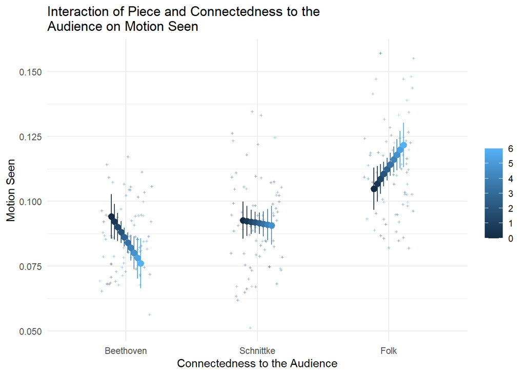

```r
piece_x_connected_audience_grid<-get_datagrid(seen_full2, at = c("piece","connected_audience"))

piece_x_connected_audience_relation<-estimate_relation(seen_full2, data = piece_x_connected_audience_grid)

vis<-visualisation_recipe(piece_x_connected_audience_relation, show_data = "point", point = list(alpha = .5, position = position_jitter(width = .2)))

plot(vis)+
  labs(title = "Interaction of Piece and Connectedness to the \nAudience on Motion Seen",
       x = "Connectedness to the Audience",
       y = "Motion Seen")+
  theme_minimal()+
  theme(legend.title = element_blank())
```

```r
graphname<-paste0("../plots/seen_piece_connAud_facet.jpg")
ggsave(graphname, width = 15, height = 9, units = 'cm', dpi = 500)
```

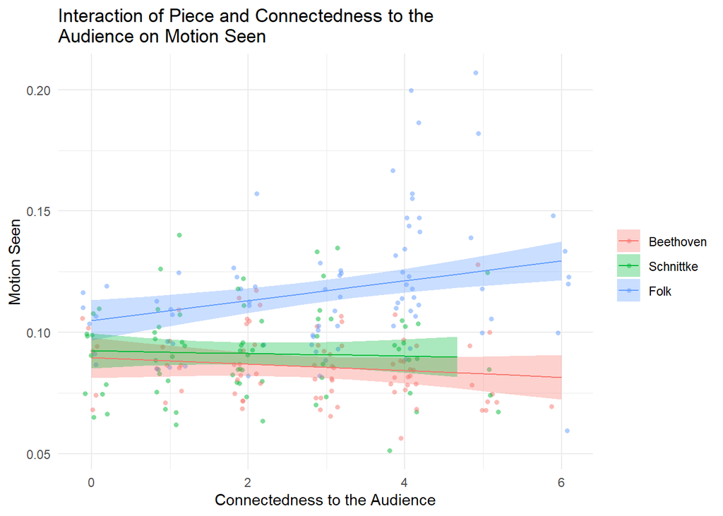

```r
connAud_x_piece<-lmer(seen ~ connected_audience * piece + (1|Pt_ID), data = seen)

piece_x_connected_audience_relation<-estimate_relation(connAud_x_piece)

vis<-visualisation_recipe(piece_x_connected_audience_relation, show_data = "point", point = list(alpha = .5, position = position_jitter(width = .2)))

plot(vis)+
  labs(title = "Interaction of Piece and Connectedness to the \nAudience on Motion Seen",
       x = "Connectedness to the Audience",
       y = "Motion Seen")+
  theme_minimal()+
  theme(legend.title = element_blank())
```

```r
graphname<-paste0("../plots/seen_piece_connAud.jpg")
ggsave(graphname, width = 15, height = 9, units = 'cm', dpi = 500)
```

## 3.5 Relations Between Concert emotions

Make Repeated Measures Correlation Chart to examine the relations between the outcome variables of interest

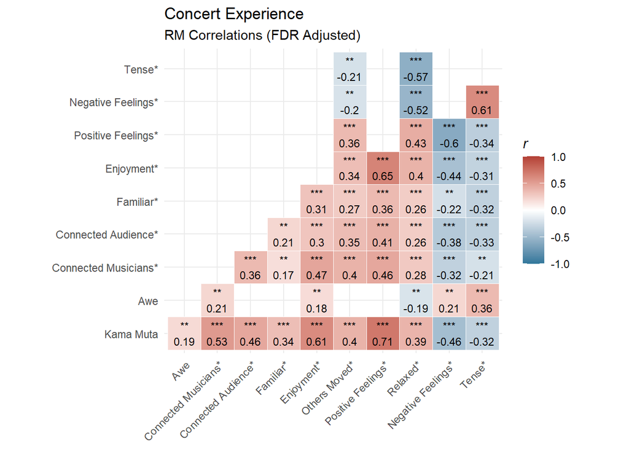

```r
cormat_df<-df.full%>%select(Pt_ID,contains("KM"), contains("AWE_wonder"), contains("connected_musicians"), contains("connected_audience"), contains("familiar"),contains("enjoy"), contains("positive"), contains("negative"), contains("tense"), contains("relaxed"), contains("others_moved"))

cormat_df.long<-cormat_df%>%pivot_longer(!Pt_ID,
                        names_to = c("var", "piece"),
                        names_pattern ="(.*)_(.*)",
                        values_to = "response")

exclude<-c("connected_audience_streaming", "connected_audience_attending","positively_transformed", "negatively_transformed", "emotionally_moved") # emotionally_moved is the question from Bach

cormat_df.long<-cormat_df.long%>%filter(! var %in% exclude)

cormat_df.wide<-pivot_wider(cormat_df.long, names_from = var, values_from = response)

# rename the vars so they appear pretty in the chart
variables<-c("Kama Muta","Awe", "Connected Musicians*", "Connected Audience*","Familiar*","Enjoyment*","Positive Feelings*", "Negative Feelings*", "Tense*", "Relaxed*", "Others Moved*")
colnames(cormat_df.wide)<-c("Pt_ID", "piece", variables)

rmc_mat<-rmcorr_mat(Pt_ID, variables, cormat_df.wide, CI.level = 0.95)

rmcorrlist<-rmc_mat$summary
rmcorrlist$p.val.adj<-p.adjust(rmcorrlist$p.vals, method = "fdr", n = length(rmcorrlist$p.vals))
rmcorrlist$rmcorr.r<-round(rmcorrlist$rmcorr.r, 2)

rmcorrlist%<>%filter(p.val.adj < .05)

rmcorrlist%<>%mutate(sig = case_when(p.val.adj>.01 ~ "*",
                                p.val.adj>.001 ~ "**",
                                p.val.adj<.001 ~ "***"))

#Arrange to make it look pretty
rmcorrlist$measure1%<>%factor(levels = c("Kama Muta", "Awe", "Connected Musicians*","Connected Audience*","Familiar*","Enjoyment*","Others Moved*", "Positive Feelings*", "Relaxed*", "Negative Feelings*", "Tense*"))
rmcorrlist$measure2%<>%factor(levels = c("Kama Muta", "Awe", "Connected Musicians*","Connected Audience*","Familiar*","Enjoyment*","Others Moved*", "Positive Feelings*", "Relaxed*", "Negative Feelings*", "Tense*"))

#rmcorrlist$measure2%<>%factor(levels = c("Awe", "Connected Musicians","Connected Audience", "Familiar", "Enjoyment"))

rmcorrlist%<>%rename("r" = "rmcorr.r")

colours_DSQ_cor<-c("#2d769a", "white","#b34036")
Title = "Concert Experience"
Subtitle = "RM Correlations (FDR Adjusted)"

con_exp_cc<-ggplot(rmcorrlist, aes(x = measure2,y = measure1, fill = r))+
  geom_tile(color = "white")+
  scale_fill_gradientn(
    colours = colours_DSQ_cor,
    limits = c(-1,1),
    name = substitute(paste(italic(r))))+
  theme_minimal()+
  theme(axis.text.x = element_text(vjust = 1, hjust = 1, angle = 45))+
  labs(title = Title,
       subtitle = Subtitle)+
  coord_fixed()+
  geom_text(aes(measure2, measure1, label = paste(sig, r, sep ="\n")), color = "black", size = 3)+
  theme(axis.title.x = element_blank(),
        axis.title.y = element_blank())

con_exp_cc
```

```r
graphname<-paste0("../plots/CC_RM_Corr_large.jpg")
ggsave(graphname, width = 15, height = 15, units = 'cm', dpi = 500)
```

### 3.5.1 Others Moved

We asked participants “To what extent do you believe audience members around you were moved?” 7-point Likert scale from 0 = Not at all to 6 = A lot. This is what is captured in the others_moved measures in df.full.

Note: this measure was collected in the exact same way from the livestreaming audience, however neighbours_ values cannot be calculated so the following analyses are only conducted on the live audience.

To understand if they could actually detect whether those around them were moved, we averaged responses on the item of “moved” from the participants who were their neighbours: left, right and the two directly in front of them. These are the same participants who were incorporated into the measure of motion_seen.

This value was calculated in a private script to avoid revealing audience member seat positions.

#### RMCORR

1. others moved
2. oneself feeling moved
3. others’ reports of how moved they were actually
4. others’ reports of KM
5. Motion seen
6. QoM

Did people actually detect if people were feeling moved? Or was it only based on whether they felt moved themselves? How could they detect this–was it based on movement?

Feeling moved and belief in others being moved around you were correlated with repeated measures correlations.

```r
df_moved_othersMoved<-df.full%>%select(Pt_ID,group, contains("moved"), contains("KM"), contains("Neighbours"), contains("mQoM"), contains("Motion_seen"))%>%select(!contains("Bach"))%>%filter(group == "Live")

df_moved_othersMoved.long<-df_moved_othersMoved%>%pivot_longer(!c(Pt_ID, group),
                        names_to = c("question", "piece"),
                        names_pattern ="(.*)_(.*)",
                        values_to = "response")

df_moved_othersMoved.wide<-df_moved_othersMoved.long%>%pivot_wider(names_from = question, values_from = response)

moved_othersmoved.rmc<-rmcorr_mat(participant = "Pt_ID", variables = c("moved", "others_moved", "KM", "Neighbours_EmoMove", "Neighbours_KamaMuta","mQoM", "Motion_seen", "Motion_seen_Max"), dataset = df_moved_othersMoved.wide)


moved_othersmoved.rmc$summary
```

```
##               measure1            measure2  df    rmcorr.r     lowerCI
## 1                moved        others_moved 165 0.420679885  0.28716190
## 2                moved                  KM 174 0.748948185  0.67590825
## 3                moved  Neighbours_EmoMove 161 0.032469863 -0.12185886
## 4                moved Neighbours_KamaMuta 162 0.111434328 -0.04254206
## 5                moved                mQoM 147 0.084859386 -0.07699114
## 6                moved         Motion_seen 155 0.006341112 -0.15044646
## 7                moved     Motion_seen_Max 155 0.013807951 -0.14313978
## 8         others_moved                  KM 165 0.528003649  0.40892991
## 9         others_moved  Neighbours_EmoMove 154 0.052839775 -0.10517427
## 10        others_moved Neighbours_KamaMuta 155 0.218494472  0.06404836
## 11        others_moved                mQoM 140 0.151155474 -0.01391836
## 12        others_moved         Motion_seen 147 0.181545811  0.02136969
## 13        others_moved     Motion_seen_Max 147 0.123930852 -0.03761877
## 14                  KM  Neighbours_EmoMove 168 0.109811630 -0.04138667
```

[output cut: 43 more lines]

```r
p.vals <- moved_othersmoved.rmc$summary$p.vals

p.vals.fdr <- p.adjust(p.vals,
                              method = "fdr",
                              n = length(p.vals))

moved_othersmoved.rmc$summary<-cbind(moved_othersmoved.rmc$summary, p.vals.fdr)
moved_othersmoved.rmc$summary
```

```
##               measure1            measure2  df    rmcorr.r     lowerCI
## 1                moved        others_moved 165 0.420679885  0.28716190
## 2                moved                  KM 174 0.748948185  0.67590825
## 3                moved  Neighbours_EmoMove 161 0.032469863 -0.12185886
## 4                moved Neighbours_KamaMuta 162 0.111434328 -0.04254206
## 5                moved                mQoM 147 0.084859386 -0.07699114
## 6                moved         Motion_seen 155 0.006341112 -0.15044646
## 7                moved     Motion_seen_Max 155 0.013807951 -0.14313978
## 8         others_moved                  KM 165 0.528003649  0.40892991
## 9         others_moved  Neighbours_EmoMove 154 0.052839775 -0.10517427
## 10        others_moved Neighbours_KamaMuta 155 0.218494472  0.06404836
## 11        others_moved                mQoM 140 0.151155474 -0.01391836
## 12        others_moved         Motion_seen 147 0.181545811  0.02136969
## 13        others_moved     Motion_seen_Max 147 0.123930852 -0.03761877
## 14                  KM  Neighbours_EmoMove 168 0.109811630 -0.04138667
```

[output cut: 43 more lines]

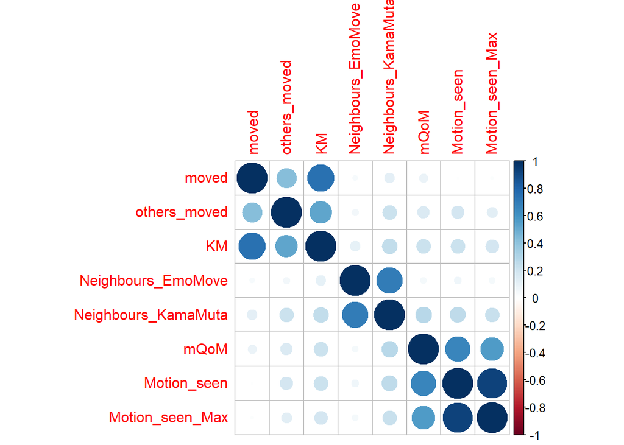

```r
require(corrplot)
corrplot(moved_othersmoved.rmc$matrix)
```

There was a rm-correlation between participants reports of others feeling moved and their reports of themselves feeling moved, full audience: r = .37, p < .001; live audience: r = .42, p < .001 .

There was no rm-correlation between participants reports of others feeling moved and their neighbours’ actual reports of feeling moved, full audience: r = .03, p = .73, live audience: r = .05, p =.62, however there was a rm-correlation between their reports of kama muta and reports of others feeling moved in the live audience, full audience r = .11, p = .22, live audience only: r = .22, p = .01.

The finding that there was a correlation between neighbours’ reports of kama muta and their reports on those around them being moved requires further investigation to ensure that it is above and beyond the influence of musical piece.

#### LME4

```r
others_moved_data<-df_moved_othersMoved.wide%>%select(-mQoM, -contains("seen"))%>%drop_na()
others_moved_w_na = others_moved_data[!complete.cases(others_moved_data), ]
others_moved_data%>%group_by(group, piece)%>%count()
```

```
## # A tibble: 3 × 3
## # Groups:   group, piece [3]
##   group piece         n
##   <fct> <chr>     <int>
## 1 Live  Beethoven    83
## 2 Live  Folk         82
## 3 Live  Schnittke    75
```

Standardize data and fit

```r
std_others_moved_data<-standardize(others_moved_data)

std_neighbours_emo_moved<-lmer(Neighbours_EmoMove ~ piece + others_moved + others_moved:piece + moved + moved:piece + (1|Pt_ID), data = std_others_moved_data)

std_neighbours_KM<-lmer(Neighbours_KamaMuta ~ piece + others_moved + others_moved:piece + KM + KM:piece + (1|Pt_ID), data = std_others_moved_data)
```

```r
#check_model(std_neighbours_emo_moved) # execute in console
check_outliers(std_neighbours_emo_moved)
```

```
## OK: No outliers detected.
## - Based on the following method and threshold: cook (0.93).
## - For variable: (Whole model)
```

```r
check_heteroscedasticity(std_neighbours_emo_moved) # no heteroscedasticity
```

```
## OK: Error variance appears to be homoscedastic (p = 0.468).
```

```r
summary(std_neighbours_emo_moved)
```

```
## Linear mixed model fit by REML. t-tests use Satterthwaite's method [
## lmerModLmerTest]
## Formula: Neighbours_EmoMove ~ piece + others_moved + others_moved:piece +
##     moved + moved:piece + (1 | Pt_ID)
##    Data: std_others_moved_data
##
## REML criterion at convergence: 661.3
##
## Scaled residuals:
##     Min      1Q  Median      3Q     Max
## -3.3577 -0.4578  0.0407  0.4931  2.2042
##
## Random effects:
##  Groups   Name        Variance Std.Dev.
##  Pt_ID    (Intercept) 0.3627   0.6022
##  Residual             0.6142   0.7837
## Number of obs: 240, groups:  Pt_ID, 85
##
## Fixed effects:
##                              Estimate Std. Error        df t value Pr(>|t|)
## (Intercept)                   0.11102    0.10854 188.50443   1.023   0.3077
## pieceFolk                    -0.07473    0.12373 153.44401  -0.604   0.5467
## pieceSchnittke               -0.25169    0.12887 158.15246  -1.953   0.0526 .
## others_moved                  0.23318    0.13970 220.65399   1.669   0.0965 .
## moved                        -0.02321    0.12723 208.97713  -0.182   0.8554
## pieceFolk:others_moved       -0.25678    0.16712 183.64249  -1.536   0.1261
## pieceSchnittke:others_moved  -0.14902    0.17817 184.35414  -0.836   0.4040
## pieceFolk:moved               0.16946    0.16825 192.95491   1.007   0.3151
## pieceSchnittke:moved         -0.03160    0.16972 185.60983  -0.186   0.8525
## ---
## Signif. codes:  0 '***' 0.001 '**' 0.01 '*' 0.05 '.' 0.1 ' ' 1
##
## Correlation of Fixed Effects:
##             (Intr) picFlk pcSchn othrs_ moved  pcFl:_ pcSc:_ pcFlk:
## pieceFolk   -0.558
## piecSchnttk -0.535  0.463
## others_movd -0.022 -0.003  0.055
## moved       -0.033  0.035  0.022 -0.632
## pcFlk:thrs_  0.013 -0.079 -0.030 -0.749  0.494
## pcSchnttk:_  0.014 -0.004  0.092 -0.700  0.462  0.540
## piecFlk:mvd  0.021  0.013  0.000  0.471 -0.711 -0.624 -0.326
## pcSchnttk:m  0.021 -0.020 -0.029  0.451 -0.688 -0.368 -0.601  0.520
```

```r
r2(std_neighbours_emo_moved)
```

```
## # R2 for Mixed Models
##
##   Conditional R2: 0.393
##      Marginal R2: 0.035
```

```r
model_dashboard(std_neighbours_emo_moved, output_file = "NeighboursFeelingMoved_dashboard.html")
```

```
##
##
## processing file: easydashboard.Rmd
```

[output not shown]

```
## output file: C:/Users/Dana/Documents/PhD/Research/MusicLab_Copenhagen/ML-Copenhagen-R-Project/Rmd/easydashboard.knit.md
```

```
## "C:/Program Files/RStudio/resources/app/bin/quarto/bin/tools/pandoc" +RTS -K512m -RTS "C:/Users/Dana/Documents/PhD/Research/MusicLab_Copenhagen/ML-Copenhagen-R-Project/Rmd/easydashboard.knit.md" --to html4 --from markdown+autolink_bare_uris+tex_math_single_backslash --output pandoc3654a9d365f.htm…
```

```
##
## Output created: NeighboursFeelingMoved_dashboard.html
```

```r
#check_model(std_neighbours_KM) # execute in console
check_outliers(std_neighbours_KM)
```

```
## OK: No outliers detected.
## - Based on the following method and threshold: cook (0.93).
## - For variable: (Whole model)
```

```r
check_heteroscedasticity(std_neighbours_KM) # no heteroscedasticity
```

```
## OK: Error variance appears to be homoscedastic (p = 0.703).
```

```r
summary(std_neighbours_KM)
```

```
## Linear mixed model fit by REML. t-tests use Satterthwaite's method [
## lmerModLmerTest]
## Formula: Neighbours_KamaMuta ~ piece + others_moved + others_moved:piece +
##     KM + KM:piece + (1 | Pt_ID)
##    Data: std_others_moved_data
##
## REML criterion at convergence: 624.4
##
## Scaled residuals:
##     Min      1Q  Median      3Q     Max
## -1.9565 -0.5300 -0.0327  0.4707  2.8975
##
## Random effects:
##  Groups   Name        Variance Std.Dev.
##  Pt_ID    (Intercept) 0.3777   0.6145
##  Residual             0.4931   0.7022
## Number of obs: 240, groups:  Pt_ID, 85
##
## Fixed effects:
##                               Estimate Std. Error         df t value Pr(>|t|)
## (Intercept)                   0.080972   0.102392 175.785180   0.791    0.430
## pieceFolk                     0.181509   0.111791 152.667733   1.624    0.107
## pieceSchnittke               -0.471636   0.116688 157.573439  -4.042 8.27e-05
## others_moved                  0.071556   0.121434 216.423080   0.589    0.556
## KM                            0.163811   0.109358 209.406203   1.498    0.136
## pieceFolk:others_moved        0.003327   0.149773 174.588577   0.022    0.982
## pieceSchnittke:others_moved   0.008449   0.155275 176.860793   0.054    0.957
## pieceFolk:KM                 -0.035867   0.152912 181.089888  -0.235    0.815
## pieceSchnittke:KM            -0.135688   0.146230 169.973009  -0.928    0.355
##
## (Intercept)
## pieceFolk
## pieceSchnittke              ***
## others_moved
## KM
## pieceFolk:others_moved
## pieceSchnittke:others_moved
## pieceFolk:KM
## pieceSchnittke:KM
## ---
## Signif. codes:  0 '***' 0.001 '**' 0.01 '*' 0.05 '.' 0.1 ' ' 1
##
## Correlation of Fixed Effects:
##             (Intr) picFlk pcSchn othrs_ KM     pcFl:_ pcSc:_ pcF:KM
## pieceFolk   -0.525
## piecSchnttk -0.503  0.450
## others_movd -0.059  0.037  0.089
## KM           0.026 -0.043 -0.009 -0.576
## pcFlk:thrs_  0.042 -0.030 -0.048 -0.689  0.402
## pcSchnttk:_  0.040 -0.034  0.017 -0.676  0.393  0.493
## pieceFlk:KM -0.024 -0.076  0.020  0.376 -0.617 -0.622 -0.258
## pcSchntt:KM -0.019  0.017  0.111  0.389 -0.618 -0.295 -0.563  0.436
```

```r
r2(std_neighbours_KM)
```

```
## # R2 for Mixed Models
##
##   Conditional R2: 0.502
##      Marginal R2: 0.120
```

```r
model_dashboard(std_neighbours_KM, output_file = "NeighboursKamaMuta_dashboard.html")
```

```
##
##
## processing file: easydashboard.Rmd
```

[output not shown]

```
## output file: C:/Users/Dana/Documents/PhD/Research/MusicLab_Copenhagen/ML-Copenhagen-R-Project/Rmd/easydashboard.knit.md
```

```
## "C:/Program Files/RStudio/resources/app/bin/quarto/bin/tools/pandoc" +RTS -K512m -RTS "C:/Users/Dana/Documents/PhD/Research/MusicLab_Copenhagen/ML-Copenhagen-R-Project/Rmd/easydashboard.knit.md" --to html4 --from markdown+autolink_bare_uris+tex_math_single_backslash --output pandoc3654394291d.htm…
```

```
##
## Output created: NeighboursKamaMuta_dashboard.html
```

#### Effect (parameter) estimates

```r
mp_satt<-model_parameters(std_neighbours_emo_moved, ci_method = "satterthwaite")
mp_satt # copy and paste into excel, convert text to table, copy into word to apply formatting.
```

```
## # Fixed Effects
##
## Parameter                        | Coefficient |   SE |        95% CI |     t |     df |     p
## ----------------------------------------------------------------------------------------------
## (Intercept)                      |        0.11 | 0.11 | [-0.10, 0.33] |  1.02 | 188.50 | 0.308
## piece [Folk]                     |       -0.07 | 0.12 | [-0.32, 0.17] | -0.60 | 153.44 | 0.547
## piece [Schnittke]                |       -0.25 | 0.13 | [-0.51, 0.00] | -1.95 | 158.15 | 0.053
## others moved                     |        0.23 | 0.14 | [-0.04, 0.51] |  1.67 | 220.65 | 0.097
## moved                            |       -0.02 | 0.13 | [-0.27, 0.23] | -0.18 | 208.98 | 0.855
## piece [Folk] × others moved      |       -0.26 | 0.17 | [-0.59, 0.07] | -1.54 | 183.64 | 0.126
## piece [Schnittke] × others moved |       -0.15 | 0.18 | [-0.50, 0.20] | -0.84 | 184.35 | 0.404
## piece [Folk] × moved             |        0.17 | 0.17 | [-0.16, 0.50] |  1.01 | 192.95 | 0.315
## piece [Schnittke] × moved        |       -0.03 | 0.17 | [-0.37, 0.30] | -0.19 | 185.61 | 0.853
##
## # Random Effects
##
## Parameter             | Coefficient |   SE |       95% CI
## ---------------------------------------------------------
## SD (Intercept: Pt_ID) |        0.60 | 0.08 | [0.47, 0.78]
## SD (Residual)         |        0.78 | 0.05 | [0.70, 0.88]
```

```
##
## Uncertainty intervals (equal-tailed) and p-values (two-tailed) computed
##   using a Wald t-distribution with Satterthwaite approximation.
```

```r
mp_satt<-model_parameters(std_neighbours_KM, ci_method = "satterthwaite")
mp_satt # copy and paste into excel, convert text to table, copy into word to apply formatting.
```

```
## # Fixed Effects
##
## Parameter                        | Coefficient |   SE |         95% CI |     t |     df |      p
## ------------------------------------------------------------------------------------------------
## (Intercept)                      |        0.08 | 0.10 | [-0.12,  0.28] |  0.79 | 175.79 | 0.430
## piece [Folk]                     |        0.18 | 0.11 | [-0.04,  0.40] |  1.62 | 152.67 | 0.107
## piece [Schnittke]                |       -0.47 | 0.12 | [-0.70, -0.24] | -4.04 | 157.57 | < .001
## others moved                     |        0.07 | 0.12 | [-0.17,  0.31] |  0.59 | 216.42 | 0.556
## KM                               |        0.16 | 0.11 | [-0.05,  0.38] |  1.50 | 209.41 | 0.136
## piece [Folk] × others moved      |    3.33e-03 | 0.15 | [-0.29,  0.30] |  0.02 | 174.59 | 0.982
## piece [Schnittke] × others moved |    8.45e-03 | 0.16 | [-0.30,  0.31] |  0.05 | 176.86 | 0.957
## piece [Folk] × KM                |       -0.04 | 0.15 | [-0.34,  0.27] | -0.23 | 181.09 | 0.815
## piece [Schnittke] × KM           |       -0.14 | 0.15 | [-0.42,  0.15] | -0.93 | 169.97 | 0.355
##
## # Random Effects
##
## Parameter             | Coefficient |   SE |       95% CI
## ---------------------------------------------------------
## SD (Intercept: Pt_ID) |        0.61 | 0.07 | [0.49, 0.77]
## SD (Residual)         |        0.70 | 0.04 | [0.63, 0.79]
```

```
##
## Uncertainty intervals (equal-tailed) and p-values (two-tailed) computed
##   using a Wald t-distribution with Satterthwaite approximation.
```